# Project: Investigate a Dataset (TMDB 5000 Movie Dataset)

### By: Mohamed Refaiy

##### Jan 2021

- Introduction
- Data Wrangling
- Exploratory Data Analysis
- Conclusions

## Introduction

> What can we say about the success of a movie before it is released? Are there certain companies (Pixar?) that have found a consistent formula? Given that major films costing over $100 million to produce can still flop, this question is more important than ever to the industry. Film aficionados might have different interests. Can we predict which films will be highly rated, whether or not they are a commercial success? This is a great place to start digging in to those questions, with data on the plot, cast, crew, budget, and revenues of several thousand films.

> This work is dedicated for **Investigate a Dataset Project**. The first project in **Data Analysis Advanced Nanodegree Program**. In this report I will illustrate the steps I took to wrangle and analyze data from TMDB 5000 Movie Dataset.

### Research Question 1 (Which genres are the successful through years)

### Research Question 2 (Is there releation between Revenues, voting and popularity)

```python
# Use this cell to set up import statements for all of the packages that you
#   plan to use.wsa
import numpy as np
import pandas as pd
import matplotlib.pyplot as plt
import matplotlib.ticker as ticker
import seaborn as sns
%matplotlib inline
sns.set_style('whitegrid')
import warnings
warnings.filterwarnings('ignore')
from datetime import datetime
```

## Data Wrangling

The **wrangle** part include 3 main steps:

1. *Gathering data* - **Direct download:** tmdb-movies.csv
2. *Assessing data* - After gathering data, assess it visually and programmatically for quality and tidiness issues
3. *Cleaning data* - Clean quality and tidiness issues

### General Properties

```python
# Load your data and print out a few lines. Perform operations to inspect data
#   types and look for instances of missing or possibly errant data.
df_movies = pd.read_csv('tmdb-movies.csv')
```

### Data Assessing

```python
df_movies.sample(25)
```

|  | id | imdb_id | popularity | budget | revenue | original_title | cast | homepage | director | tagline | ... | overview | runtime | genres | production_companies | release_date | vote_count | vote_average | release_year | budget_adj | revenue_adj |
| --- | --- | --- | --- | --- | --- | --- | --- | --- | --- | --- | --- | --- | --- | --- | --- | --- | --- | --- | --- | --- | --- |
| 6526 | 11214 | tt0478324 | 0.097543 | 0 | 0 | We Feed the World - Essen Global | Jean Ziegler\|Peter Brabeck\|Karl Otrok | http://www.we-feed-the-world.at/index.htm | Erwin Wagenhofer | NaN | ... | A documentary that exposes the shocking truths... | 96 | Documentary\|Foreign | NaN | 9/10/05 | 11 | 7.5 | 2005 | 0.000000e+00 | 0.000000e+00 |
| 1502 | 18781 | tt0492044 | 0.729008 | 0 | 77527732 | The Haunting in Connecticut | Virginia Madsen\|Kyle Gallner\|Martin Donovan\|Am... | http://www.hauntinginconnecticut.com/ | Peter Cornwell | Some things cannot be explained. | ... | When the Campbell family moves to upstate Conn... | 102 | Thriller\|Horror | Lionsgate\|Gold Circle Films\|Integrated Films | 3/27/09 | 141 | 6.1 | 2009 | 0.000000e+00 | 7.879922e+07 |
| 8222 | 11876 | tt0113362 | 0.194078 | 35000000 | 15000000 | Le Hussard sur le toit | Juliette Binoche\|Olivier Martinez\|Pierre Ardit... | NaN | Jean-Paul Rappeneau | NaN | ... | In a time of war and disease, a young officer ... | 135 | War\|Adventure\|Drama\|Romance | France 2 Cinéma\|Hachette Première\|Canal+ | 9/20/95 | 17 | 6.4 | 1995 | 5.008384e+07 | 2.146450e+07 |
| 8436 | 13555 | tt0082427 | 0.161586 | 0 | 0 | The Funhouse | Elizabeth Berridge\|Shawn Carson\|Jeanne Austin\|... | NaN | Tobe Hooper | Pay to get in. PRAY to get out. | ... | Rebellious teen Amy (Elizabeth Berridge) defie... | 96 | Horror | Mace Neufeld Productions | 3/13/81 | 17 | 6.0 | 1981 | 0.000000e+00 | 0.000000e+00 |
| 5948 | 176570 | tt1764647 | 0.140690 | 0 | 0 | Shadow People | Dallas Roberts\|Alison Eastwood\|Anne Dudek\|Mari... | NaN | Matthew Arnold | NaN | ... | A radio talk show host unravels a conspiracy a... | 89 | Thriller | NaN | 3/17/13 | 19 | 5.2 | 2013 | 0.000000e+00 | 0.000000e+00 |
| 9426 | 2071 | tt0102900 | 0.192123 | 22000000 | 11511031 | Shattered | Tom Berenger\|Bob Hoskins\|Greta Scacchi\|Joanne ... | NaN | Wolfgang Petersen | NaN | ... | Dan Merrick comes out from a shattering car ac... | 98 | Mystery\|Thriller | Palace Pictures\|Metro-Goldwyn-Mayer (MGM) | 10/11/91 | 11 | 6.5 | 1991 | 3.522404e+07 | 1.843023e+07 |
| 210 | 283235 | tt2891174 | 0.661471 | 8000000 | 1411927 | 99 Homes | Andrew Garfield\|Laura Dern\|Michael Shannon\|Tim... | NaN | Ramin Bahrani | Greed is the only game in town. | ... | After his family is evicted from their home, p... | 112 | Drama | Imagenation Abu Dhabi FZ\|Hyde Park Entertainme... | 9/25/15 | 121 | 6.8 | 2015 | 7.359997e+06 | 1.298972e+06 |
| 4400 | 123025 | tt2313197 | 1.686513 | 3500000 | 0 | Batman: The Dark Knight Returns, Part 1 | Peter Weller\|Ariel Winter\|David Selby\|Wade Wil... | NaN | Jay Oliva | Old heroes never die. They just get darker. | ... | Batman has not been seen for ten years. A new ... | 76 | Action\|Animation | DC Comics\|Warner Bros. Animation\|Warner Premie... | 9/6/12 | 248 | 7.6 | 2012 | 3.324105e+06 | 0.000000e+00 |
| 7637 | 13501 | tt0484111 | 0.323370 | 15000000 | 20380 | The Good Night | Penélope Cruz\|Martin Freeman\|Gwyneth Paltrow\|... | NaN | Jake Paltrow | Dreaming is believing. | ... | Gary, a musician, is trapped in an unhappy rel... | 93 | Comedy\|Drama\|Romance\|Fantasy\|Music | Destination Films\|Tempesta Films\|Good Night Pr... | 1/25/07 | 16 | 5.5 | 2007 | 1.577503e+07 | 2.143301e+04 |
| 850 | 276902 | tt1661820 | 0.621645 | 5000000 | 0 | Cut Bank | Liam Hemsworth\|Teresa Palmer\|John Malkovich\|Br... | NaN | Matt Shakman | Good Folks. Bad Deeds. | ... | 25 year-old Dwayne McLaren, a former athlete t... | 92 | Thriller | Kilburn Media | 9/10/14 | 52 | 4.8 | 2014 | 4.605455e+06 | 0.000000e+00 |
| 8328 | 16219 | tt0104346 | 0.291459 | 0 | 9 | Gladiator | James Marshall\|Cuba Gooding Jr.\|Robert Loggia\|... | NaN | Rowdy Herrington | Nobody owns Tommy Riley. Nobody. | ... | A story of two teenagers trapped in the world ... | 101 | Action\|Drama | Columbia Pictures Corporation | 3/6/92 | 10 | 5.1 | 1992 | 0.000000e+00 | 1.398622e+01 |
| 6688 | 13205 | tt0447854 | 0.609691 | 0 | 0 | Bambi II | Patrick Stewart\|Alexander Gould\|Brendon Baerg\|... | NaN | Brian Pimental | A Son's Courage. A Father's Love. | ... | Picking up shortly after the original movie's ... | 72 | Animation\|Drama\|Family | Walt Disney Pictures | 2/1/06 | 109 | 5.9 | 2006 | 0.000000e+00 | 0.000000e+00 |
| 1411 | 22794 | tt0844471 | 1.849649 | 100000000 | 242988466 | Cloudy with a Chance of Meatballs | Bill Hader\|Anna Faris\|James Caan\|Mr. T\|Benjami... | http://www.cloudywithachanceofmeatballs.com/ | Phil Lord\|Christopher Miller | Prepare to get served. | ... | Inventor Flint Lockwood creates a machine that... | 90 | Animation\|Comedy\|Family | Columbia Pictures\|Sony Pictures Animation | 9/17/09 | 1116 | 6.4 | 2009 | 1.016400e+08 | 2.469736e+08 |
| 6775 | 9841 | tt0787505 | 0.350497 | 0 | 0 | Rest Stop | Jaimie Alexander\|Joey Mendicino\|Deanna Russo\|D... | NaN | John Shiban | NaN | ... | The film follows Nicole Carrow, a young woman ... | 80 | Horror\|Thriller | Warner Home Video\|Flame Ventures\|Raw Feed\|Papa... | 10/7/06 | 28 | 5.0 | 2006 | 0.000000e+00 | 0.000000e+00 |
| 4387 | 62213 | tt1077368 | 2.092701 | 150000000 | 245527149 | Dark Shadows | Johnny Depp\|Michelle Pfeiffer\|Helena Bonham Ca... | http://darkshadowsmovie.warnerbros.com | Tim Burton | Every Family Has Its Demons | ... | Vampire Barnabas Collins is inadvertently free... | 113 | Comedy\|Fantasy | Village Roadshow Pictures\|Infinitum Nihil\|GK F... | 5/8/12 | 1434 | 5.6 | 2012 | 1.424616e+08 | 2.331880e+08 |
| 3108 | 14215 | tt0441782 | 0.393140 | 0 | 0 | Restraint | Travis Fimmel\|Teresa Palmer\|Stephen Moyer\|Phil... | NaN | David Denneen | Seclusion. Seduction. Survival. | ... | Two fugitives land in hot water when they take... | 94 | Drama\|Thriller | Filmgraphics Entertainment\|Film Finance | 8/19/08 | 19 | 6.1 | 2008 | 0.000000e+00 | 0.000000e+00 |
| 5202 | 246355 | tt0495241 | 0.121449 | 0 | 0 | Saw | Leigh Whannell\|Paul Moder\|Katrina Mathers\|Dean... | NaN | James Wan | NaN | ... | Saw is an Australian nine-and-a-half-minute sh... | 9 | Crime\|Thriller\|Horror | Twisted Pictures | 1/1/03 | 40 | 6.4 | 2003 | 0.000000e+00 | 0.000000e+00 |
| 29 | 294254 | tt4046784 | 3.968891 | 61000000 | 311256926 | Maze Runner: The Scorch Trials | Dylan O'Brien\|Kaya Scodelario\|Thomas Brodie-Sa... | http://mazerunnermovies.com | Wes Ball | The Maze Was Just the Beginning. | ... | Thomas and his fellow Gladers face their great... | 132 | Action\|Science Fiction\|Thriller | Gotham Group\|Temple Hill Entertainment\|TSG Ent... | 9/9/15 | 1849 | 6.4 | 2015 | 5.611998e+07 | 2.863562e+08 |
| 4568 | 91679 | tt2035630 | 0.477554 | 0 | 0 | Starlet | Dree Hemingway\|Besedka Johnson\|Stella Maeve\|Ja... | http://www.facebook.com/StarletFilm | Sean Baker | NaN | ... | A young woman finds a fortune stashed in a yar... | 103 | Drama | NaN | 11/9/12 | 21 | 6.5 | 2012 | 0.000000e+00 | 0.000000e+00 |
| 10200 | 19971 | tt0074806 | 0.264423 | 0 | 0 | The Little Girl Who Lives Down the Lane | Jodie Foster\|Martin Sheen\|Alexis Smith\|Mort Sh... | NaN | Nicolas Gessner | Ask her no questions, she'll tell you no lies.... | ... | Quiet, withdrawn 13-year-old Rynn Jacobs lives... | 91 | Mystery\|Drama\|Thriller | Braun Entertainment Group\|Filmel\|Carnelian Pro... | 12/25/76 | 34 | 6.8 | 1976 | 0.000000e+00 | 0.000000e+00 |
| 4347 | 38940 | tt0110490 | 0.113355 | 0 | 0 | Men of War | Dolph Lundgren\|Charlotte Lewis\|BD Wong\|Tim Gui... | NaN | Perry Lang | Killers for hire are paid for what they can do... | ... | Nick Gunar is a burnt-out, jaded and hard-up f... | 103 | Action\|Thriller | Signature Pictures\|MDP Worldwide\|Pomarance Cor... | 9/4/94 | 17 | 5.3 | 1994 | 0.000000e+00 | 0.000000e+00 |
| 2138 | 48466 | tt1725156 | 0.449761 | 0 | 0 | Scared Shrekless | Mike Myers\|Cameron Diaz\|Antonio Banderas\|Dean ... | NaN | Gary Trousdale\|Raman Hui | NaN | ... | Shrek challenges Donkey, Puss in Boots and his... | 21 | Animation\|Comedy | DreamWorks Animation | 10/28/10 | 49 | 6.4 | 2010 | 0.000000e+00 | 0.000000e+00 |
| 5814 | 207774 | tt2781832 | 0.270285 | 0 | 0 | The Borderlands | Robin Hill\|Gordon Kennedy\|Aidan McArdle\|Patric... | NaN | Elliot Goldner | Evil has a new form. | ... | Vatican investigators are sent to the British ... | 89 | Horror | Metrodome Distribution | 8/24/13 | 35 | 5.0 | 2013 | 0.000000e+00 | 0.000000e+00 |
| 3209 | 14833 | tt0837796 | 0.245327 | 0 | 0 | House | Michael Madsen\|Reynaldo Rosales\|Heidi Dippold\|... | http://housethemovie.net/ | Robby Henson | NaN | ... | Trying to recover from the nearly marriage-bre... | 101 | Drama\|Horror\|Thriller | Namesake Entertainment\|More Entertainment\|Reel... | 11/6/08 | 10 | 4.0 | 2008 | 0.000000e+00 | 0.000000e+00 |
| 3219 | 3511 | tt0906734 | 0.447804 | 6700000 | 0 | The Brøken | Lena Headey\|Ulrich Thomsen\|Melvil Poupaud\|Mich... | NaN | Sean Ellis | Face your fears. | ... | The life of a successful radiologist spirals o... | 88 | Thriller\|Drama\|Horror | Gaumont\|Left Turn Films\|Ugly Duckling Films\|Ga... | 1/18/08 | 31 | 5.0 | 2008 | 6.785670e+06 | 0.000000e+00 |

25 rows × 21 columns

```python
df_movies.info()
```

```
<class 'pandas.core.frame.DataFrame'>
RangeIndex: 10866 entries, 0 to 10865
Data columns (total 21 columns):
 #   Column                Non-Null Count  Dtype
---  ------                --------------  -----
 0   id                    10866 non-null  int64
 1   imdb_id               10856 non-null  object
 2   popularity            10866 non-null  float64
 3   budget                10866 non-null  int64
 4   revenue               10866 non-null  int64
 5   original_title        10866 non-null  object
 6   cast                  10790 non-null  object
 7   homepage              2936 non-null   object
 8   director              10822 non-null  object
 9   tagline               8042 non-null   object
 10  keywords              9373 non-null   object
 11  overview              10862 non-null  object
 12  runtime               10866 non-null  int64
 13  genres                10843 non-null  object
 14  production_companies  9836 non-null   object
 15  release_date          10866 non-null  object
 16  vote_count            10866 non-null  int64
 17  vote_average          10866 non-null  float64
 18  release_year          10866 non-null  int64
 19  budget_adj            10866 non-null  float64
 20  revenue_adj           10866 non-null  float64
dtypes: float64(4), int64(6), object(11)
memory usage: 1.7+ MB
```

```python
df_movies.describe()
```

|  | id | popularity | budget | revenue | runtime | vote_count | vote_average | release_year | budget_adj | revenue_adj |
| --- | --- | --- | --- | --- | --- | --- | --- | --- | --- | --- |
| count | 10866.000000 | 10866.000000 | 1.086600e+04 | 1.086600e+04 | 10866.000000 | 10866.000000 | 10866.000000 | 10866.000000 | 1.086600e+04 | 1.086600e+04 |
| mean | 66064.177434 | 0.646441 | 1.462570e+07 | 3.982332e+07 | 102.070863 | 217.389748 | 5.974922 | 2001.322658 | 1.755104e+07 | 5.136436e+07 |
| std | 92130.136561 | 1.000185 | 3.091321e+07 | 1.170035e+08 | 31.381405 | 575.619058 | 0.935142 | 12.812941 | 3.430616e+07 | 1.446325e+08 |
| min | 5.000000 | 0.000065 | 0.000000e+00 | 0.000000e+00 | 0.000000 | 10.000000 | 1.500000 | 1960.000000 | 0.000000e+00 | 0.000000e+00 |
| 25% | 10596.250000 | 0.207583 | 0.000000e+00 | 0.000000e+00 | 90.000000 | 17.000000 | 5.400000 | 1995.000000 | 0.000000e+00 | 0.000000e+00 |
| 50% | 20669.000000 | 0.383856 | 0.000000e+00 | 0.000000e+00 | 99.000000 | 38.000000 | 6.000000 | 2006.000000 | 0.000000e+00 | 0.000000e+00 |
| 75% | 75610.000000 | 0.713817 | 1.500000e+07 | 2.400000e+07 | 111.000000 | 145.750000 | 6.600000 | 2011.000000 | 2.085325e+07 | 3.369710e+07 |
| max | 417859.000000 | 32.985763 | 4.250000e+08 | 2.781506e+09 | 900.000000 | 9767.000000 | 9.200000 | 2015.000000 | 4.250000e+08 | 2.827124e+09 |

```python
df_movies[df_movies.duplicated()]
```

|  | id | imdb_id | popularity | budget | revenue | original_title | cast | homepage | director | tagline | ... | overview | runtime | genres | production_companies | release_date | vote_count | vote_average | release_year | budget_adj | revenue_adj |
| --- | --- | --- | --- | --- | --- | --- | --- | --- | --- | --- | --- | --- | --- | --- | --- | --- | --- | --- | --- | --- | --- |
| 2090 | 42194 | tt0411951 | 0.59643 | 30000000 | 967000 | TEKKEN | Jon Foo\|Kelly Overton\|Cary-Hiroyuki Tagawa\|Ian... | NaN | Dwight H. Little | Survival is no game | ... | In the year of 2039, after World Wars destroy ... | 92 | Crime\|Drama\|Action\|Thriller\|Science Fiction | Namco\|Light Song Films | 3/20/10 | 110 | 5.0 | 2010 | 30000000.0 | 967000.0 |

1 rows × 21 columns

```python
df_movies.genres.nunique()
```

```
2039
```

```python
df_movies[(df_movies['budget_adj']==0) | (df_movies['budget']==0)].equals(df_movies[(df_movies['budget_adj']==0) & (df_movies['budget']==0)])
```

```
True
```

```python
df_movies[(df_movies['revenue_adj']==0) | (df_movies['revenue']==0)].equals(df_movies[(df_movies['revenue_adj']==0) & (df_movies['revenue']==0)])
```

```
True
```

```python
df_movies.info()
```

```
<class 'pandas.core.frame.DataFrame'>
RangeIndex: 10866 entries, 0 to 10865
Data columns (total 21 columns):
 #   Column                Non-Null Count  Dtype
---  ------                --------------  -----
 0   id                    10866 non-null  int64
 1   imdb_id               10856 non-null  object
 2   popularity            10866 non-null  float64
 3   budget                10866 non-null  int64
 4   revenue               10866 non-null  int64
 5   original_title        10866 non-null  object
 6   cast                  10790 non-null  object
 7   homepage              2936 non-null   object
 8   director              10822 non-null  object
 9   tagline               8042 non-null   object
 10  keywords              9373 non-null   object
 11  overview              10862 non-null  object
 12  runtime               10866 non-null  int64
 13  genres                10843 non-null  object
 14  production_companies  9836 non-null   object
 15  release_date          10866 non-null  object
 16  vote_count            10866 non-null  int64
 17  vote_average          10866 non-null  float64
 18  release_year          10866 non-null  int64
 19  budget_adj            10866 non-null  float64
 20  revenue_adj           10866 non-null  float64
dtypes: float64(4), int64(6), object(11)
memory usage: 1.7+ MB
```

### Create copy of Dataframe

```python
df= df_movies.copy()
```

#### Drop duplicated rows

```python
# drop duplicated rows
df.drop_duplicates(keep = 'first', inplace = True)
```

```python
# test
df[df.duplicated()]
```

|  | id | imdb_id | popularity | budget | revenue | original_title | cast | homepage | director | tagline | ... | overview | runtime | genres | production_companies | release_date | vote_count | vote_average | release_year | budget_adj | revenue_adj |
| --- | --- | --- | --- | --- | --- | --- | --- | --- | --- | --- | --- | --- | --- | --- | --- | --- | --- | --- | --- | --- | --- |

0 rows × 21 columns

#### drop columns:

> - budget
> - revenue
> - homepage
> - tagline
> - overview
> - production_companies

```python
# drop columns
df.drop(['budget','revenue','homepage','tagline','overview','production_companies'], axis = 1,inplace=True  )
```

#### convert release_date to date type

1. delete the 2 digit of year
2. add the 4 digit year from column **release_year**
3. convert column to datetime type

```python
# remove 2 digit year
df["release_date"]= df["release_date"].str[:-2]
df["release_date"]
```

```
0          6/9/
1         5/13/
2         3/18/
3        12/15/
4          4/1/
          ...
10861     6/15/
10862    12/21/
10863      1/1/
10864     11/2/
10865    11/15/
Name: release_date, Length: 10865, dtype: object
```

```python
# add 4 digit year
#convert release_date to date type
df['release_date'] =  df["release_date"] + df["release_year"].astype('str')
df['release_date']
```

```
0          6/9/2015
1         5/13/2015
2         3/18/2015
3        12/15/2015
4          4/1/2015
            ...
10861     6/15/1966
10862    12/21/1966
10863      1/1/1966
10864     11/2/1966
10865    11/15/1966
Name: release_date, Length: 10865, dtype: object
```

```python
# convert to date type
df['release_date'] = pd.to_datetime(df['release_date'])
```

```python
# test
df['release_date']
```

```
0       2015-06-09
1       2015-05-13
2       2015-03-18
3       2015-12-15
4       2015-04-01
           ...
10861   1966-06-15
10862   1966-12-21
10863   1966-01-01
10864   1966-11-02
10865   1966-11-15
Name: release_date, Length: 10865, dtype: datetime64[ns]
```

### Replace 0 values with nan in columns budget_adj and revenue_adj

> - **Movies with 0 budget can be cosidred with low budget**

```python
# replace 0 values with nan in columns budget_adj and revenue_adj
df['budget_adj'] = df['budget_adj'].replace(0, np.nan)
df['revenue_adj'] = df['revenue_adj'].replace(0, np.nan)
```

```python
# test
df.info()
```

```
<class 'pandas.core.frame.DataFrame'>
Int64Index: 10865 entries, 0 to 10865
Data columns (total 15 columns):
 #   Column          Non-Null Count  Dtype
---  ------          --------------  -----
 0   id              10865 non-null  int64
 1   imdb_id         10855 non-null  object
 2   popularity      10865 non-null  float64
 3   original_title  10865 non-null  object
 4   cast            10789 non-null  object
 5   director        10821 non-null  object
 6   keywords        9372 non-null   object
 7   runtime         10865 non-null  int64
 8   genres          10842 non-null  object
 9   release_date    10865 non-null  datetime64[ns]
 10  vote_count      10865 non-null  int64
 11  vote_average    10865 non-null  float64
 12  release_year    10865 non-null  int64
 13  budget_adj      5169 non-null   float64
 14  revenue_adj     4849 non-null   float64
dtypes: datetime64[ns](1), float64(4), int64(4), object(6)
memory usage: 1.3+ MB
```

#### Seperate genres

> - creata New dataframe with sepreate genres
> - concat genres to new df

```python
# extrct budget for each genre
genres= df['genres'].str.get_dummies(sep = "|")
```

```python
#test
genres
```

|  | Action | Adventure | Animation | Comedy | Crime | Documentary | Drama | Family | Fantasy | Foreign | History | Horror | Music | Mystery | Romance | Science Fiction | TV Movie | Thriller | War | Western |
| --- | --- | --- | --- | --- | --- | --- | --- | --- | --- | --- | --- | --- | --- | --- | --- | --- | --- | --- | --- | --- |
| 0 | 1 | 1 | 0 | 0 | 0 | 0 | 0 | 0 | 0 | 0 | 0 | 0 | 0 | 0 | 0 | 1 | 0 | 1 | 0 | 0 |
| 1 | 1 | 1 | 0 | 0 | 0 | 0 | 0 | 0 | 0 | 0 | 0 | 0 | 0 | 0 | 0 | 1 | 0 | 1 | 0 | 0 |
| 2 | 0 | 1 | 0 | 0 | 0 | 0 | 0 | 0 | 0 | 0 | 0 | 0 | 0 | 0 | 0 | 1 | 0 | 1 | 0 | 0 |
| 3 | 1 | 1 | 0 | 0 | 0 | 0 | 0 | 0 | 1 | 0 | 0 | 0 | 0 | 0 | 0 | 1 | 0 | 0 | 0 | 0 |
| 4 | 1 | 0 | 0 | 0 | 1 | 0 | 0 | 0 | 0 | 0 | 0 | 0 | 0 | 0 | 0 | 0 | 0 | 1 | 0 | 0 |
| ... | ... | ... | ... | ... | ... | ... | ... | ... | ... | ... | ... | ... | ... | ... | ... | ... | ... | ... | ... | ... |
| 10861 | 0 | 0 | 0 | 0 | 0 | 1 | 0 | 0 | 0 | 0 | 0 | 0 | 0 | 0 | 0 | 0 | 0 | 0 | 0 | 0 |
| 10862 | 1 | 1 | 0 | 0 | 0 | 0 | 1 | 0 | 0 | 0 | 0 | 0 | 0 | 0 | 0 | 0 | 0 | 0 | 0 | 0 |
| 10863 | 0 | 0 | 0 | 1 | 0 | 0 | 0 | 0 | 0 | 0 | 0 | 0 | 0 | 1 | 0 | 0 | 0 | 0 | 0 | 0 |
| 10864 | 1 | 0 | 0 | 1 | 0 | 0 | 0 | 0 | 0 | 0 | 0 | 0 | 0 | 0 | 0 | 0 | 0 | 0 | 0 | 0 |
| 10865 | 0 | 0 | 0 | 0 | 0 | 0 | 0 | 0 | 0 | 0 | 0 | 1 | 0 | 0 | 0 | 0 | 0 | 0 | 0 | 0 |

10865 rows × 20 columns

```python
# add new genres columns
df = df.join(df['genres'].str.get_dummies('|'))
```

```python
# test
df
```

|  | id | imdb_id | popularity | original_title | cast | director | keywords | runtime | genres | release_date | ... | History | Horror | Music | Mystery | Romance | Science Fiction | TV Movie | Thriller | War | Western |
| --- | --- | --- | --- | --- | --- | --- | --- | --- | --- | --- | --- | --- | --- | --- | --- | --- | --- | --- | --- | --- | --- |
| 0 | 135397 | tt0369610 | 32.985763 | Jurassic World | Chris Pratt\|Bryce Dallas Howard\|Irrfan Khan\|Vi... | Colin Trevorrow | monster\|dna\|tyrannosaurus rex\|velociraptor\|island | 124 | Action\|Adventure\|Science Fiction\|Thriller | 2015-06-09 | ... | 0 | 0 | 0 | 0 | 0 | 1 | 0 | 1 | 0 | 0 |
| 1 | 76341 | tt1392190 | 28.419936 | Mad Max: Fury Road | Tom Hardy\|Charlize Theron\|Hugh Keays-Byrne\|Nic... | George Miller | future\|chase\|post-apocalyptic\|dystopia\|australia | 120 | Action\|Adventure\|Science Fiction\|Thriller | 2015-05-13 | ... | 0 | 0 | 0 | 0 | 0 | 1 | 0 | 1 | 0 | 0 |
| 2 | 262500 | tt2908446 | 13.112507 | Insurgent | Shailene Woodley\|Theo James\|Kate Winslet\|Ansel... | Robert Schwentke | based on novel\|revolution\|dystopia\|sequel\|dyst... | 119 | Adventure\|Science Fiction\|Thriller | 2015-03-18 | ... | 0 | 0 | 0 | 0 | 0 | 1 | 0 | 1 | 0 | 0 |
| 3 | 140607 | tt2488496 | 11.173104 | Star Wars: The Force Awakens | Harrison Ford\|Mark Hamill\|Carrie Fisher\|Adam D... | J.J. Abrams | android\|spaceship\|jedi\|space opera\|3d | 136 | Action\|Adventure\|Science Fiction\|Fantasy | 2015-12-15 | ... | 0 | 0 | 0 | 0 | 0 | 1 | 0 | 0 | 0 | 0 |
| 4 | 168259 | tt2820852 | 9.335014 | Furious 7 | Vin Diesel\|Paul Walker\|Jason Statham\|Michelle ... | James Wan | car race\|speed\|revenge\|suspense\|car | 137 | Action\|Crime\|Thriller | 2015-04-01 | ... | 0 | 0 | 0 | 0 | 0 | 0 | 0 | 1 | 0 | 0 |
| ... | ... | ... | ... | ... | ... | ... | ... | ... | ... | ... | ... | ... | ... | ... | ... | ... | ... | ... | ... | ... | ... |
| 10861 | 21 | tt0060371 | 0.080598 | The Endless Summer | Michael Hynson\|Robert August\|Lord 'Tally Ho' B... | Bruce Brown | surfer\|surfboard\|surfing | 95 | Documentary | 1966-06-15 | ... | 0 | 0 | 0 | 0 | 0 | 0 | 0 | 0 | 0 | 0 |
| 10862 | 20379 | tt0060472 | 0.065543 | Grand Prix | James Garner\|Eva Marie Saint\|Yves Montand\|Tosh... | John Frankenheimer | car race\|racing\|formula 1 | 176 | Action\|Adventure\|Drama | 1966-12-21 | ... | 0 | 0 | 0 | 0 | 0 | 0 | 0 | 0 | 0 | 0 |
| 10863 | 39768 | tt0060161 | 0.065141 | Beregis Avtomobilya | Innokentiy Smoktunovskiy\|Oleg Efremov\|Georgi Z... | Eldar Ryazanov | car\|trolley\|stealing car | 94 | Mystery\|Comedy | 1966-01-01 | ... | 0 | 0 | 0 | 1 | 0 | 0 | 0 | 0 | 0 | 0 |
| 10864 | 21449 | tt0061177 | 0.064317 | What's Up, Tiger Lily? | Tatsuya Mihashi\|Akiko Wakabayashi\|Mie Hama\|Joh... | Woody Allen | spoof | 80 | Action\|Comedy | 1966-11-02 | ... | 0 | 0 | 0 | 0 | 0 | 0 | 0 | 0 | 0 | 0 |
| 10865 | 22293 | tt0060666 | 0.035919 | Manos: The Hands of Fate | Harold P. Warren\|Tom Neyman\|John Reynolds\|Dian... | Harold P. Warren | fire\|gun\|drive\|sacrifice\|flashlight | 74 | Horror | 1966-11-15 | ... | 0 | 1 | 0 | 0 | 0 | 0 | 0 | 0 | 0 | 0 |

10865 rows × 35 columns

## Exploratory Data Analysis

> **Tip**: Now that you've trimmed and cleaned your data, you're ready to move on to exploration. Compute statistics and create visualizations with the goal of addressing the research questions that you posed in the Introduction section. It is recommended that you be systematic with your approach. Look at one variable at a time, and then follow it up by looking at relationships between variables.

### Research Question 1 (Which genres are the successful through years)

> - **First let's calculate movies count per every year**

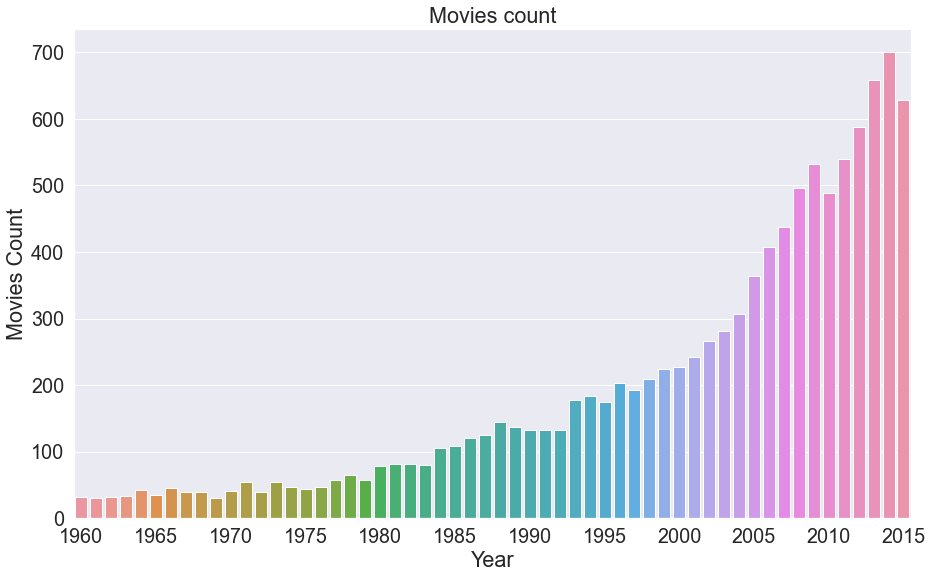

```python
sns.set(font_scale=1.8)
fig_dims = (15, 9)
fig, ax = plt.subplots(figsize=fig_dims)
g = sns.countplot(x="release_year", data=df)
g.set(xlabel= 'Year', ylabel='Movies Count', title='Movies count')
ax.xaxis.set_major_locator(ticker.MultipleLocator(base=5));
```

> **There is a noticeable increase in movies count per year**

```python
genres = pd.concat([df['release_year'],genres], axis=1)
```

```python
genres
```

|  | release_year | Action | Adventure | Animation | Comedy | Crime | Documentary | Drama | Family | Fantasy | ... | History | Horror | Music | Mystery | Romance | Science Fiction | TV Movie | Thriller | War | Western |
| --- | --- | --- | --- | --- | --- | --- | --- | --- | --- | --- | --- | --- | --- | --- | --- | --- | --- | --- | --- | --- | --- |
| 0 | 2015 | 1 | 1 | 0 | 0 | 0 | 0 | 0 | 0 | 0 | ... | 0 | 0 | 0 | 0 | 0 | 1 | 0 | 1 | 0 | 0 |
| 1 | 2015 | 1 | 1 | 0 | 0 | 0 | 0 | 0 | 0 | 0 | ... | 0 | 0 | 0 | 0 | 0 | 1 | 0 | 1 | 0 | 0 |
| 2 | 2015 | 0 | 1 | 0 | 0 | 0 | 0 | 0 | 0 | 0 | ... | 0 | 0 | 0 | 0 | 0 | 1 | 0 | 1 | 0 | 0 |
| 3 | 2015 | 1 | 1 | 0 | 0 | 0 | 0 | 0 | 0 | 1 | ... | 0 | 0 | 0 | 0 | 0 | 1 | 0 | 0 | 0 | 0 |
| 4 | 2015 | 1 | 0 | 0 | 0 | 1 | 0 | 0 | 0 | 0 | ... | 0 | 0 | 0 | 0 | 0 | 0 | 0 | 1 | 0 | 0 |
| ... | ... | ... | ... | ... | ... | ... | ... | ... | ... | ... | ... | ... | ... | ... | ... | ... | ... | ... | ... | ... | ... |
| 10861 | 1966 | 0 | 0 | 0 | 0 | 0 | 1 | 0 | 0 | 0 | ... | 0 | 0 | 0 | 0 | 0 | 0 | 0 | 0 | 0 | 0 |
| 10862 | 1966 | 1 | 1 | 0 | 0 | 0 | 0 | 1 | 0 | 0 | ... | 0 | 0 | 0 | 0 | 0 | 0 | 0 | 0 | 0 | 0 |
| 10863 | 1966 | 0 | 0 | 0 | 1 | 0 | 0 | 0 | 0 | 0 | ... | 0 | 0 | 0 | 1 | 0 | 0 | 0 | 0 | 0 | 0 |
| 10864 | 1966 | 1 | 0 | 0 | 1 | 0 | 0 | 0 | 0 | 0 | ... | 0 | 0 | 0 | 0 | 0 | 0 | 0 | 0 | 0 | 0 |
| 10865 | 1966 | 0 | 0 | 0 | 0 | 0 | 0 | 0 | 0 | 0 | ... | 0 | 1 | 0 | 0 | 0 | 0 | 0 | 0 | 0 | 0 |

10865 rows × 21 columns

```python
# sum each genre per year
genres_year = genres.groupby(['release_year'] ).sum()
```

```python
genres_year
```

| release_year | Action | Adventure | Animation | Comedy | Crime | Documentary | Drama | Family | Fantasy | Foreign | History | Horror | Music | Mystery | Romance | Science Fiction | TV Movie | Thriller | War | Western |
| --- | --- | --- | --- | --- | --- | --- | --- | --- | --- | --- | --- | --- | --- | --- | --- | --- | --- | --- | --- | --- |
| 1960 | 8 | 5 | 0 | 8 | 2 | 0 | 13 | 3 | 2 | 1 | 5 | 7 | 1 | 0 | 6 | 3 | 0 | 6 | 2 | 6 |
| 1961 | 7 | 6 | 1 | 10 | 2 | 0 | 16 | 5 | 2 | 1 | 3 | 3 | 2 | 1 | 7 | 4 | 0 | 0 | 2 | 3 |
| 1962 | 8 | 7 | 0 | 5 | 3 | 0 | 21 | 2 | 1 | 1 | 4 | 5 | 1 | 4 | 5 | 2 | 0 | 7 | 3 | 3 |
| 1963 | 4 | 7 | 1 | 13 | 4 | 0 | 13 | 3 | 2 | 2 | 4 | 9 | 0 | 6 | 8 | 2 | 0 | 10 | 1 | 2 |
| 1964 | 5 | 5 | 2 | 16 | 10 | 0 | 20 | 4 | 4 | 1 | 3 | 6 | 5 | 4 | 9 | 4 | 0 | 9 | 3 | 1 |
| 1965 | 9 | 6 | 1 | 7 | 2 | 0 | 20 | 3 | 0 | 1 | 4 | 5 | 2 | 3 | 5 | 2 | 1 | 11 | 8 | 4 |
| 1966 | 14 | 11 | 3 | 16 | 5 | 1 | 16 | 7 | 2 | 2 | 2 | 3 | 0 | 6 | 6 | 6 | 0 | 8 | 4 | 7 |
| 1967 | 7 | 7 | 2 | 17 | 7 | 1 | 16 | 3 | 3 | 0 | 0 | 4 | 5 | 3 | 11 | 4 | 0 | 5 | 1 | 2 |
| 1968 | 6 | 5 | 3 | 9 | 5 | 0 | 20 | 5 | 5 | 0 | 3 | 4 | 3 | 4 | 6 | 4 | 0 | 5 | 4 | 1 |
| 1969 | 10 | 5 | 3 | 12 | 3 | 0 | 13 | 4 | 2 | 0 | 3 | 1 | 2 | 1 | 4 | 3 | 1 | 3 | 3 | 7 |
| 1970 | 11 | 6 | 2 | 12 | 4 | 3 | 19 | 3 | 3 | 1 | 3 | 5 | 4 | 3 | 6 | 3 | 1 | 5 | 5 | 8 |
| 1971 | 11 | 5 | 1 | 9 | 10 | 0 | 30 | 2 | 2 | 0 | 3 | 7 | 1 | 6 | 9 | 6 | 1 | 17 | 4 | 5 |
| 1972 | 10 | 5 | 1 | 13 | 7 | 1 | 16 | 2 | 1 | 0 | 0 | 8 | 2 | 4 | 5 | 4 | 0 | 10 | 0 | 5 |
| 1973 | 15 | 5 | 3 | 8 | 17 | 1 | 31 | 4 | 1 | 0 | 2 | 15 | 1 | 7 | 3 | 6 | 1 | 16 | 0 | 4 |
| 1974 | 14 | 8 | 1 | 12 | 15 | 2 | 21 | 4 | 3 | 0 | 1 | 8 | 1 | 5 | 4 | 5 | 1 | 20 | 1 | 2 |
| 1975 | 10 | 8 | 1 | 12 | 6 | 1 | 17 | 2 | 4 | 0 | 3 | 8 | 3 | 8 | 2 | 11 | 0 | 13 | 2 | 3 |
| 1976 | 13 | 6 | 0 | 12 | 8 | 1 | 22 | 3 | 2 | 1 | 2 | 9 | 3 | 7 | 5 | 5 | 1 | 17 | 2 | 3 |
| 1977 | 14 | 15 | 5 | 11 | 2 | 1 | 24 | 8 | 9 | 0 | 4 | 14 | 3 | 5 | 4 | 11 | 0 | 12 | 4 | 1 |
| 1978 | 15 | 11 | 2 | 14 | 6 | 3 | 29 | 6 | 5 | 1 | 2 | 19 | 3 | 7 | 5 | 16 | 3 | 22 | 4 | 1 |
| 1979 | 8 | 8 | 1 | 19 | 8 | 0 | 30 | 5 | 0 | 0 | 3 | 11 | 4 | 4 | 8 | 10 | 0 | 16 | 3 | 4 |
| 1980 | 27 | 14 | 0 | 25 | 9 | 0 | 32 | 4 | 7 | 2 | 5 | 16 | 4 | 9 | 9 | 11 | 1 | 25 | 2 | 5 |
| 1981 | 17 | 14 | 3 | 20 | 10 | 2 | 32 | 5 | 3 | 0 | 5 | 24 | 3 | 10 | 10 | 10 | 1 | 27 | 2 | 0 |
| 1982 | 17 | 10 | 6 | 28 | 9 | 1 | 33 | 8 | 13 | 2 | 2 | 20 | 6 | 10 | 12 | 13 | 1 | 17 | 2 | 2 |
| 1983 | 21 | 14 | 3 | 28 | 11 | 0 | 35 | 4 | 10 | 1 | 1 | 13 | 5 | 5 | 14 | 16 | 1 | 24 | 1 | 1 |
| 1984 | 33 | 22 | 1 | 38 | 15 | 2 | 40 | 9 | 15 | 0 | 5 | 18 | 11 | 4 | 19 | 27 | 1 | 24 | 3 | 0 |
| 1985 | 28 | 28 | 2 | 51 | 14 | 1 | 40 | 12 | 14 | 0 | 1 | 14 | 2 | 3 | 21 | 17 | 0 | 24 | 2 | 3 |
| 1986 | 30 | 17 | 7 | 49 | 18 | 0 | 51 | 13 | 11 | 0 | 3 | 30 | 6 | 7 | 25 | 21 | 0 | 23 | 4 | 1 |
| 1987 | 29 | 17 | 4 | 57 | 21 | 0 | 52 | 16 | 18 | 0 | 3 | 25 | 4 | 7 | 24 | 18 | 2 | 28 | 6 | 1 |
| 1988 | 32 | 15 | 7 | 69 | 21 | 5 | 54 | 17 | 16 | 1 | 4 | 36 | 8 | 9 | 19 | 18 | 2 | 33 | 6 | 0 |
| 1989 | 38 | 24 | 5 | 63 | 25 | 2 | 54 | 17 | 16 | 2 | 4 | 25 | 3 | 8 | 22 | 21 | 0 | 35 | 4 | 1 |
| 1990 | 39 | 23 | 4 | 48 | 30 | 1 | 60 | 12 | 13 | 1 | 4 | 26 | 2 | 14 | 19 | 18 | 1 | 46 | 2 | 3 |
| 1991 | 39 | 21 | 3 | 60 | 20 | 3 | 63 | 21 | 19 | 3 | 1 | 13 | 7 | 9 | 26 | 13 | 0 | 37 | 2 | 2 |
| 1992 | 34 | 17 | 4 | 54 | 25 | 1 | 65 | 16 | 14 | 3 | 4 | 16 | 6 | 10 | 31 | 16 | 0 | 45 | 1 | 2 |
| 1993 | 53 | 26 | 6 | 72 | 28 | 1 | 90 | 29 | 13 | 5 | 8 | 18 | 6 | 15 | 34 | 18 | 0 | 45 | 6 | 3 |
| 1994 | 61 | 33 | 8 | 88 | 26 | 2 | 83 | 35 | 24 | 3 | 3 | 13 | 3 | 10 | 35 | 20 | 5 | 45 | 3 | 8 |
| 1995 | 47 | 32 | 7 | 63 | 31 | 2 | 93 | 33 | 17 | 2 | 7 | 19 | 0 | 14 | 37 | 18 | 1 | 49 | 5 | 3 |
| 1996 | 42 | 30 | 8 | 91 | 19 | 3 | 104 | 31 | 22 | 2 | 5 | 17 | 4 | 13 | 44 | 24 | 2 | 61 | 3 | 0 |
| 1997 | 59 | 35 | 10 | 77 | 28 | 2 | 83 | 33 | 21 | 3 | 7 | 18 | 4 | 21 | 32 | 29 | 1 | 61 | 1 | 0 |
| 1998 | 43 | 38 | 16 | 84 | 34 | 3 | 108 | 34 | 22 | 4 | 7 | 23 | 12 | 18 | 41 | 26 | 3 | 53 | 3 | 1 |
| 1999 | 38 | 20 | 13 | 100 | 29 | 5 | 113 | 29 | 23 | 6 | 7 | 26 | 5 | 24 | 42 | 29 | 6 | 53 | 3 | 3 |
| 2000 | 47 | 28 | 27 | 97 | 31 | 3 | 101 | 34 | 21 | 4 | 4 | 21 | 10 | 14 | 47 | 24 | 1 | 63 | 5 | 2 |
| 2001 | 61 | 40 | 18 | 101 | 39 | 5 | 100 | 31 | 25 | 4 | 12 | 23 | 6 | 22 | 53 | 25 | 10 | 66 | 12 | 2 |
| 2002 | 72 | 45 | 21 | 104 | 41 | 10 | 130 | 39 | 20 | 11 | 8 | 30 | 4 | 28 | 48 | 28 | 3 | 84 | 7 | 1 |
| 2003 | 73 | 41 | 29 | 111 | 46 | 11 | 110 | 44 | 27 | 5 | 9 | 24 | 11 | 19 | 49 | 41 | 3 | 73 | 8 | 4 |
| 2004 | 75 | 49 | 23 | 125 | 32 | 12 | 141 | 40 | 19 | 7 | 7 | 29 | 13 | 27 | 63 | 34 | 6 | 74 | 8 | 7 |
| 2005 | 70 | 53 | 26 | 143 | 45 | 17 | 182 | 57 | 35 | 10 | 10 | 56 | 13 | 29 | 62 | 25 | 3 | 92 | 5 | 2 |
| 2006 | 80 | 55 | 39 | 155 | 53 | 16 | 197 | 65 | 34 | 10 | 12 | 56 | 12 | 30 | 70 | 30 | 8 | 114 | 7 | 1 |
| 2007 | 95 | 60 | 32 | 151 | 65 | 19 | 197 | 45 | 47 | 17 | 13 | 79 | 15 | 34 | 74 | 41 | 6 | 125 | 6 | 5 |
| 2008 | 99 | 63 | 33 | 169 | 62 | 26 | 233 | 56 | 43 | 18 | 24 | 76 | 20 | 29 | 84 | 52 | 5 | 127 | 18 | 2 |
| 2009 | 108 | 72 | 48 | 198 | 52 | 25 | 224 | 60 | 49 | 17 | 16 | 90 | 17 | 51 | 83 | 71 | 8 | 157 | 12 | 0 |
| 2010 | 107 | 59 | 50 | 169 | 50 | 35 | 210 | 55 | 44 | 13 | 14 | 78 | 10 | 32 | 85 | 45 | 8 | 134 | 7 | 6 |
| 2011 | 115 | 62 | 46 | 172 | 48 | 49 | 214 | 72 | 46 | 14 | 8 | 78 | 17 | 38 | 75 | 56 | 10 | 146 | 9 | 3 |
| 2012 | 99 | 50 | 40 | 176 | 54 | 49 | 232 | 42 | 34 | 6 | 13 | 104 | 22 | 33 | 79 | 54 | 14 | 160 | 10 | 4 |
| 2013 | 121 | 67 | 42 | 175 | 71 | 62 | 253 | 48 | 39 | 0 | 14 | 102 | 30 | 38 | 65 | 61 | 10 | 175 | 7 | 3 |
| 2014 | 129 | 67 | 36 | 185 | 65 | 73 | 284 | 43 | 36 | 0 | 15 | 105 | 28 | 36 | 84 | 62 | 14 | 179 | 23 | 6 |
| 2015 | 107 | 69 | 39 | 162 | 51 | 57 | 260 | 44 | 33 | 0 | 15 | 125 | 33 | 42 | 57 | 86 | 20 | 171 | 9 | 6 |

```python
genres.sum().sort_values(ascending =False)
```

```
release_year       21744362
Drama                  4760
Comedy                 3793
Thriller               2907
Action                 2384
Romance                1712
Horror                 1637
Adventure              1471
Crime                  1354
Family                 1231
Science Fiction        1229
Fantasy                 916
Mystery                 810
Animation               699
Documentary             520
Music                   408
History                 334
War                     270
Foreign                 188
TV Movie                167
Western                 165
dtype: int64
```

> - **Drama category is the most produced**

```python
#https://stackoverflow.com/questions/34518634/finding-highest-values-in-each-row-in-a-data-frame-for-python
# get top 5 genres per year
top_n = 5
top_f_genres = pd.DataFrame({n: genres_year.T[col].nlargest(top_n).index.tolist()
         for n, col in enumerate(genres_year.T)}).T
```

```python
top_f_genres
```

|  | 0 | 1 | 2 | 3 | 4 |
| --- | --- | --- | --- | --- | --- |
| 0 | Drama | Action | Comedy | Horror | Romance |
| 1 | Drama | Comedy | Action | Romance | Adventure |
| 2 | Drama | Action | Adventure | Thriller | Comedy |
| 3 | Comedy | Drama | Thriller | Horror | Romance |
| 4 | Drama | Comedy | Crime | Romance | Thriller |
| 5 | Drama | Thriller | Action | War | Comedy |
| 6 | Comedy | Drama | Action | Adventure | Thriller |
| 7 | Comedy | Drama | Romance | Action | Adventure |
| 8 | Drama | Comedy | Action | Romance | Adventure |
| 9 | Drama | Comedy | Action | Western | Adventure |
| 10 | Drama | Comedy | Action | Western | Adventure |
| 11 | Drama | Thriller | Action | Crime | Comedy |
| 12 | Drama | Comedy | Action | Thriller | Horror |
| 13 | Drama | Crime | Thriller | Action | Horror |
| 14 | Drama | Thriller | Crime | Action | Comedy |
| 15 | Drama | Thriller | Comedy | Science Fiction | Action |
| 16 | Drama | Thriller | Action | Comedy | Horror |
| 17 | Drama | Adventure | Action | Horror | Thriller |
| 18 | Drama | Thriller | Horror | Science Fiction | Action |
| 19 | Drama | Comedy | Thriller | Horror | Science Fiction |
| 20 | Drama | Action | Comedy | Thriller | Horror |
| 21 | Drama | Thriller | Horror | Comedy | Action |
| 22 | Drama | Comedy | Horror | Action | Thriller |
| 23 | Drama | Comedy | Thriller | Action | Science Fiction |
| 24 | Drama | Comedy | Action | Science Fiction | Thriller |
| 25 | Comedy | Drama | Action | Adventure | Thriller |
| 26 | Drama | Comedy | Action | Horror | Romance |
| 27 | Comedy | Drama | Action | Thriller | Horror |
| 28 | Comedy | Drama | Horror | Thriller | Action |
| 29 | Comedy | Drama | Action | Thriller | Crime |
| 30 | Drama | Comedy | Thriller | Action | Crime |
| 31 | Drama | Comedy | Action | Thriller | Romance |
| 32 | Drama | Comedy | Thriller | Action | Romance |
| 33 | Drama | Comedy | Action | Thriller | Romance |
| 34 | Comedy | Drama | Action | Thriller | Family |
| 35 | Drama | Comedy | Thriller | Action | Romance |
| 36 | Drama | Comedy | Thriller | Romance | Action |
| 37 | Drama | Comedy | Thriller | Action | Adventure |
| 38 | Drama | Comedy | Thriller | Action | Romance |
| 39 | Drama | Comedy | Thriller | Romance | Action |
| 40 | Drama | Comedy | Thriller | Action | Romance |
| 41 | Comedy | Drama | Thriller | Action | Romance |
| 42 | Drama | Comedy | Thriller | Action | Romance |
| 43 | Comedy | Drama | Action | Thriller | Romance |
| 44 | Drama | Comedy | Action | Thriller | Romance |
| 45 | Drama | Comedy | Thriller | Action | Romance |
| 46 | Drama | Comedy | Thriller | Action | Romance |
| 47 | Drama | Comedy | Thriller | Action | Horror |
| 48 | Drama | Comedy | Thriller | Action | Romance |
| 49 | Drama | Comedy | Thriller | Action | Horror |
| 50 | Drama | Comedy | Thriller | Action | Romance |
| 51 | Drama | Comedy | Thriller | Action | Horror |
| 52 | Drama | Comedy | Thriller | Horror | Action |
| 53 | Drama | Comedy | Thriller | Action | Horror |
| 54 | Drama | Comedy | Thriller | Action | Horror |
| 55 | Drama | Thriller | Comedy | Horror | Action |

```python
# rename column
top_f_genres.rename(columns = {0:'1st_genre', 1:'2nd_genre',
                        2:'3rd_genre',3:'4th_genre',4:'5th_genre'}, inplace = True)
top_f_genres
```

|  | 1st_genre | 2nd_genre | 3rd_genre | 4th_genre | 5th_genre |
| --- | --- | --- | --- | --- | --- |
| 0 | Drama | Action | Comedy | Horror | Romance |
| 1 | Drama | Comedy | Action | Romance | Adventure |
| 2 | Drama | Action | Adventure | Thriller | Comedy |
| 3 | Comedy | Drama | Thriller | Horror | Romance |
| 4 | Drama | Comedy | Crime | Romance | Thriller |
| 5 | Drama | Thriller | Action | War | Comedy |
| 6 | Comedy | Drama | Action | Adventure | Thriller |
| 7 | Comedy | Drama | Romance | Action | Adventure |
| 8 | Drama | Comedy | Action | Romance | Adventure |
| 9 | Drama | Comedy | Action | Western | Adventure |
| 10 | Drama | Comedy | Action | Western | Adventure |
| 11 | Drama | Thriller | Action | Crime | Comedy |
| 12 | Drama | Comedy | Action | Thriller | Horror |
| 13 | Drama | Crime | Thriller | Action | Horror |
| 14 | Drama | Thriller | Crime | Action | Comedy |
| 15 | Drama | Thriller | Comedy | Science Fiction | Action |
| 16 | Drama | Thriller | Action | Comedy | Horror |
| 17 | Drama | Adventure | Action | Horror | Thriller |
| 18 | Drama | Thriller | Horror | Science Fiction | Action |
| 19 | Drama | Comedy | Thriller | Horror | Science Fiction |
| 20 | Drama | Action | Comedy | Thriller | Horror |
| 21 | Drama | Thriller | Horror | Comedy | Action |
| 22 | Drama | Comedy | Horror | Action | Thriller |
| 23 | Drama | Comedy | Thriller | Action | Science Fiction |
| 24 | Drama | Comedy | Action | Science Fiction | Thriller |
| 25 | Comedy | Drama | Action | Adventure | Thriller |
| 26 | Drama | Comedy | Action | Horror | Romance |
| 27 | Comedy | Drama | Action | Thriller | Horror |
| 28 | Comedy | Drama | Horror | Thriller | Action |
| 29 | Comedy | Drama | Action | Thriller | Crime |
| 30 | Drama | Comedy | Thriller | Action | Crime |
| 31 | Drama | Comedy | Action | Thriller | Romance |
| 32 | Drama | Comedy | Thriller | Action | Romance |
| 33 | Drama | Comedy | Action | Thriller | Romance |
| 34 | Comedy | Drama | Action | Thriller | Family |
| 35 | Drama | Comedy | Thriller | Action | Romance |
| 36 | Drama | Comedy | Thriller | Romance | Action |
| 37 | Drama | Comedy | Thriller | Action | Adventure |
| 38 | Drama | Comedy | Thriller | Action | Romance |
| 39 | Drama | Comedy | Thriller | Romance | Action |
| 40 | Drama | Comedy | Thriller | Action | Romance |
| 41 | Comedy | Drama | Thriller | Action | Romance |
| 42 | Drama | Comedy | Thriller | Action | Romance |
| 43 | Comedy | Drama | Action | Thriller | Romance |
| 44 | Drama | Comedy | Action | Thriller | Romance |
| 45 | Drama | Comedy | Thriller | Action | Romance |
| 46 | Drama | Comedy | Thriller | Action | Romance |
| 47 | Drama | Comedy | Thriller | Action | Horror |
| 48 | Drama | Comedy | Thriller | Action | Romance |
| 49 | Drama | Comedy | Thriller | Action | Horror |
| 50 | Drama | Comedy | Thriller | Action | Romance |
| 51 | Drama | Comedy | Thriller | Action | Horror |
| 52 | Drama | Comedy | Thriller | Horror | Action |
| 53 | Drama | Comedy | Thriller | Action | Horror |
| 54 | Drama | Comedy | Thriller | Action | Horror |
| 55 | Drama | Thriller | Comedy | Horror | Action |

```python
top_f_genres.max()
```

```
1st_genre       Drama
2nd_genre    Thriller
3rd_genre    Thriller
4th_genre     Western
5th_genre    Thriller
dtype: object
```

```python
# calculate each count of top 5 genres
top_f_count = genres_year * -1
top_f_count = top_f_count.apply(np.sort, axis = 1)
top_f_count = top_f_count * -1
top_f_count = top_f_count.to_frame()
```

```python
top_f_count.loc[:, '1st_genre_count'] = top_f_count[0].map(lambda x: x[0])
top_f_count.loc[:, '2nd_genre_count'] = top_f_count[0].map(lambda x: x[1])
top_f_count.loc[:, '3rd_genre_count'] = top_f_count[0].map(lambda x: x[2])
top_f_count.loc[:, '4th_genre_count'] = top_f_count[0].map(lambda x: x[3])
top_f_count.loc[:, '5th_genre_count'] = top_f_count[0].map(lambda x: x[4])
```

```python
top_f_count.reset_index(inplace=True)
top_f_count.drop([0],inplace=True,axis=1)
```

```python
top_f_count
```

|  | release_year | 1st_genre_count | 2nd_genre_count | 3rd_genre_count | 4th_genre_count | 5th_genre_count |
| --- | --- | --- | --- | --- | --- | --- |
| 0 | 1960 | 13 | 8 | 8 | 7 | 6 |
| 1 | 1961 | 16 | 10 | 7 | 7 | 6 |
| 2 | 1962 | 21 | 8 | 7 | 7 | 5 |
| 3 | 1963 | 13 | 13 | 10 | 9 | 8 |
| 4 | 1964 | 20 | 16 | 10 | 9 | 9 |
| 5 | 1965 | 20 | 11 | 9 | 8 | 7 |
| 6 | 1966 | 16 | 16 | 14 | 11 | 8 |
| 7 | 1967 | 17 | 16 | 11 | 7 | 7 |
| 8 | 1968 | 20 | 9 | 6 | 6 | 5 |
| 9 | 1969 | 13 | 12 | 10 | 7 | 5 |
| 10 | 1970 | 19 | 12 | 11 | 8 | 6 |
| 11 | 1971 | 30 | 17 | 11 | 10 | 9 |
| 12 | 1972 | 16 | 13 | 10 | 10 | 8 |
| 13 | 1973 | 31 | 17 | 16 | 15 | 15 |
| 14 | 1974 | 21 | 20 | 15 | 14 | 12 |
| 15 | 1975 | 17 | 13 | 12 | 11 | 10 |
| 16 | 1976 | 22 | 17 | 13 | 12 | 9 |
| 17 | 1977 | 24 | 15 | 14 | 14 | 12 |
| 18 | 1978 | 29 | 22 | 19 | 16 | 15 |
| 19 | 1979 | 30 | 19 | 16 | 11 | 10 |
| 20 | 1980 | 32 | 27 | 25 | 25 | 16 |
| 21 | 1981 | 32 | 27 | 24 | 20 | 17 |
| 22 | 1982 | 33 | 28 | 20 | 17 | 17 |
| 23 | 1983 | 35 | 28 | 24 | 21 | 16 |
| 24 | 1984 | 40 | 38 | 33 | 27 | 24 |
| 25 | 1985 | 51 | 40 | 28 | 28 | 24 |
| 26 | 1986 | 51 | 49 | 30 | 30 | 25 |
| 27 | 1987 | 57 | 52 | 29 | 28 | 25 |
| 28 | 1988 | 69 | 54 | 36 | 33 | 32 |
| 29 | 1989 | 63 | 54 | 38 | 35 | 25 |
| 30 | 1990 | 60 | 48 | 46 | 39 | 30 |
| 31 | 1991 | 63 | 60 | 39 | 37 | 26 |
| 32 | 1992 | 65 | 54 | 45 | 34 | 31 |
| 33 | 1993 | 90 | 72 | 53 | 45 | 34 |
| 34 | 1994 | 88 | 83 | 61 | 45 | 35 |
| 35 | 1995 | 93 | 63 | 49 | 47 | 37 |
| 36 | 1996 | 104 | 91 | 61 | 44 | 42 |
| 37 | 1997 | 83 | 77 | 61 | 59 | 35 |
| 38 | 1998 | 108 | 84 | 53 | 43 | 41 |
| 39 | 1999 | 113 | 100 | 53 | 42 | 38 |
| 40 | 2000 | 101 | 97 | 63 | 47 | 47 |
| 41 | 2001 | 101 | 100 | 66 | 61 | 53 |
| 42 | 2002 | 130 | 104 | 84 | 72 | 48 |
| 43 | 2003 | 111 | 110 | 73 | 73 | 49 |
| 44 | 2004 | 141 | 125 | 75 | 74 | 63 |
| 45 | 2005 | 182 | 143 | 92 | 70 | 62 |
| 46 | 2006 | 197 | 155 | 114 | 80 | 70 |
| 47 | 2007 | 197 | 151 | 125 | 95 | 79 |
| 48 | 2008 | 233 | 169 | 127 | 99 | 84 |
| 49 | 2009 | 224 | 198 | 157 | 108 | 90 |
| 50 | 2010 | 210 | 169 | 134 | 107 | 85 |
| 51 | 2011 | 214 | 172 | 146 | 115 | 78 |
| 52 | 2012 | 232 | 176 | 160 | 104 | 99 |
| 53 | 2013 | 253 | 175 | 175 | 121 | 102 |
| 54 | 2014 | 284 | 185 | 179 | 129 | 105 |
| 55 | 2015 | 260 | 171 | 162 | 125 | 107 |

```python
top_f_count.mean()
```

```
release_year       1987.500000
1st_genre_count      85.857143
2nd_genre_count      68.089286
3rd_genre_count      53.017857
4th_genre_count      42.464286
5th_genre_count      35.053571
dtype: float64
```

```python
# merge genres with counts
top_f = pd.concat([top_f_count,top_f_genres], axis=1)
```

```python
top_f
```

|  | release_year | 1st_genre_count | 2nd_genre_count | 3rd_genre_count | 4th_genre_count | 5th_genre_count | 1st_genre | 2nd_genre | 3rd_genre | 4th_genre | 5th_genre |
| --- | --- | --- | --- | --- | --- | --- | --- | --- | --- | --- | --- |
| 0 | 1960 | 13 | 8 | 8 | 7 | 6 | Drama | Action | Comedy | Horror | Romance |
| 1 | 1961 | 16 | 10 | 7 | 7 | 6 | Drama | Comedy | Action | Romance | Adventure |
| 2 | 1962 | 21 | 8 | 7 | 7 | 5 | Drama | Action | Adventure | Thriller | Comedy |
| 3 | 1963 | 13 | 13 | 10 | 9 | 8 | Comedy | Drama | Thriller | Horror | Romance |
| 4 | 1964 | 20 | 16 | 10 | 9 | 9 | Drama | Comedy | Crime | Romance | Thriller |
| 5 | 1965 | 20 | 11 | 9 | 8 | 7 | Drama | Thriller | Action | War | Comedy |
| 6 | 1966 | 16 | 16 | 14 | 11 | 8 | Comedy | Drama | Action | Adventure | Thriller |
| 7 | 1967 | 17 | 16 | 11 | 7 | 7 | Comedy | Drama | Romance | Action | Adventure |
| 8 | 1968 | 20 | 9 | 6 | 6 | 5 | Drama | Comedy | Action | Romance | Adventure |
| 9 | 1969 | 13 | 12 | 10 | 7 | 5 | Drama | Comedy | Action | Western | Adventure |
| 10 | 1970 | 19 | 12 | 11 | 8 | 6 | Drama | Comedy | Action | Western | Adventure |
| 11 | 1971 | 30 | 17 | 11 | 10 | 9 | Drama | Thriller | Action | Crime | Comedy |
| 12 | 1972 | 16 | 13 | 10 | 10 | 8 | Drama | Comedy | Action | Thriller | Horror |
| 13 | 1973 | 31 | 17 | 16 | 15 | 15 | Drama | Crime | Thriller | Action | Horror |
| 14 | 1974 | 21 | 20 | 15 | 14 | 12 | Drama | Thriller | Crime | Action | Comedy |
| 15 | 1975 | 17 | 13 | 12 | 11 | 10 | Drama | Thriller | Comedy | Science Fiction | Action |
| 16 | 1976 | 22 | 17 | 13 | 12 | 9 | Drama | Thriller | Action | Comedy | Horror |
| 17 | 1977 | 24 | 15 | 14 | 14 | 12 | Drama | Adventure | Action | Horror | Thriller |
| 18 | 1978 | 29 | 22 | 19 | 16 | 15 | Drama | Thriller | Horror | Science Fiction | Action |
| 19 | 1979 | 30 | 19 | 16 | 11 | 10 | Drama | Comedy | Thriller | Horror | Science Fiction |
| 20 | 1980 | 32 | 27 | 25 | 25 | 16 | Drama | Action | Comedy | Thriller | Horror |
| 21 | 1981 | 32 | 27 | 24 | 20 | 17 | Drama | Thriller | Horror | Comedy | Action |
| 22 | 1982 | 33 | 28 | 20 | 17 | 17 | Drama | Comedy | Horror | Action | Thriller |
| 23 | 1983 | 35 | 28 | 24 | 21 | 16 | Drama | Comedy | Thriller | Action | Science Fiction |
| 24 | 1984 | 40 | 38 | 33 | 27 | 24 | Drama | Comedy | Action | Science Fiction | Thriller |
| 25 | 1985 | 51 | 40 | 28 | 28 | 24 | Comedy | Drama | Action | Adventure | Thriller |
| 26 | 1986 | 51 | 49 | 30 | 30 | 25 | Drama | Comedy | Action | Horror | Romance |
| 27 | 1987 | 57 | 52 | 29 | 28 | 25 | Comedy | Drama | Action | Thriller | Horror |
| 28 | 1988 | 69 | 54 | 36 | 33 | 32 | Comedy | Drama | Horror | Thriller | Action |
| 29 | 1989 | 63 | 54 | 38 | 35 | 25 | Comedy | Drama | Action | Thriller | Crime |
| 30 | 1990 | 60 | 48 | 46 | 39 | 30 | Drama | Comedy | Thriller | Action | Crime |
| 31 | 1991 | 63 | 60 | 39 | 37 | 26 | Drama | Comedy | Action | Thriller | Romance |
| 32 | 1992 | 65 | 54 | 45 | 34 | 31 | Drama | Comedy | Thriller | Action | Romance |
| 33 | 1993 | 90 | 72 | 53 | 45 | 34 | Drama | Comedy | Action | Thriller | Romance |
| 34 | 1994 | 88 | 83 | 61 | 45 | 35 | Comedy | Drama | Action | Thriller | Family |
| 35 | 1995 | 93 | 63 | 49 | 47 | 37 | Drama | Comedy | Thriller | Action | Romance |
| 36 | 1996 | 104 | 91 | 61 | 44 | 42 | Drama | Comedy | Thriller | Romance | Action |
| 37 | 1997 | 83 | 77 | 61 | 59 | 35 | Drama | Comedy | Thriller | Action | Adventure |
| 38 | 1998 | 108 | 84 | 53 | 43 | 41 | Drama | Comedy | Thriller | Action | Romance |
| 39 | 1999 | 113 | 100 | 53 | 42 | 38 | Drama | Comedy | Thriller | Romance | Action |
| 40 | 2000 | 101 | 97 | 63 | 47 | 47 | Drama | Comedy | Thriller | Action | Romance |
| 41 | 2001 | 101 | 100 | 66 | 61 | 53 | Comedy | Drama | Thriller | Action | Romance |
| 42 | 2002 | 130 | 104 | 84 | 72 | 48 | Drama | Comedy | Thriller | Action | Romance |
| 43 | 2003 | 111 | 110 | 73 | 73 | 49 | Comedy | Drama | Action | Thriller | Romance |
| 44 | 2004 | 141 | 125 | 75 | 74 | 63 | Drama | Comedy | Action | Thriller | Romance |
| 45 | 2005 | 182 | 143 | 92 | 70 | 62 | Drama | Comedy | Thriller | Action | Romance |
| 46 | 2006 | 197 | 155 | 114 | 80 | 70 | Drama | Comedy | Thriller | Action | Romance |
| 47 | 2007 | 197 | 151 | 125 | 95 | 79 | Drama | Comedy | Thriller | Action | Horror |
| 48 | 2008 | 233 | 169 | 127 | 99 | 84 | Drama | Comedy | Thriller | Action | Romance |
| 49 | 2009 | 224 | 198 | 157 | 108 | 90 | Drama | Comedy | Thriller | Action | Horror |
| 50 | 2010 | 210 | 169 | 134 | 107 | 85 | Drama | Comedy | Thriller | Action | Romance |
| 51 | 2011 | 214 | 172 | 146 | 115 | 78 | Drama | Comedy | Thriller | Action | Horror |
| 52 | 2012 | 232 | 176 | 160 | 104 | 99 | Drama | Comedy | Thriller | Horror | Action |
| 53 | 2013 | 253 | 175 | 175 | 121 | 102 | Drama | Comedy | Thriller | Action | Horror |
| 54 | 2014 | 284 | 185 | 179 | 129 | 105 | Drama | Comedy | Thriller | Action | Horror |
| 55 | 2015 | 260 | 171 | 162 | 125 | 107 | Drama | Thriller | Comedy | Horror | Action |

```python
#add budget_adj','revenue_adj to dataframe
top_f = pd.concat([top_f,df.groupby(['release_year'], as_index=False)['budget_adj','revenue_adj']
                   .mean().drop(['release_year'],axis=1)], axis=1)
```

```python
top_f
```

|  | release_year | 1st_genre_count | 2nd_genre_count | 3rd_genre_count | 4th_genre_count | 5th_genre_count | 1st_genre | 2nd_genre | 3rd_genre | 4th_genre | 5th_genre | budget_adj | revenue_adj |
| --- | --- | --- | --- | --- | --- | --- | --- | --- | --- | --- | --- | --- | --- |
| 0 | 1960 | 13 | 8 | 8 | 7 | 6 | Drama | Action | Comedy | Horror | Romance | 1.806946e+07 | 1.527310e+08 |
| 1 | 1961 | 16 | 10 | 7 | 7 | 6 | Drama | Comedy | Action | Romance | Adventure | 2.588946e+07 | 2.463622e+08 |
| 2 | 1962 | 21 | 8 | 7 | 7 | 5 | Drama | Action | Adventure | Thriller | Comedy | 2.817583e+07 | 1.726663e+08 |
| 3 | 1963 | 13 | 13 | 10 | 9 | 8 | Comedy | Drama | Thriller | Horror | Romance | 4.746668e+07 | 1.906224e+08 |
| 4 | 1964 | 20 | 16 | 10 | 9 | 9 | Drama | Comedy | Crime | Romance | Thriller | 2.523429e+07 | 2.996491e+08 |
| 5 | 1965 | 20 | 11 | 9 | 8 | 7 | Drama | Thriller | Action | War | Comedy | 4.416900e+07 | 6.340369e+08 |
| 6 | 1966 | 16 | 16 | 14 | 11 | 8 | Comedy | Drama | Action | Adventure | Thriller | 3.222117e+07 | 1.138525e+08 |
| 7 | 1967 | 17 | 16 | 11 | 7 | 7 | Comedy | Drama | Romance | Action | Adventure | 3.655220e+07 | 3.445036e+08 |
| 8 | 1968 | 20 | 9 | 6 | 6 | 5 | Drama | Comedy | Action | Romance | Adventure | 3.006553e+07 | 1.383001e+08 |
| 9 | 1969 | 13 | 12 | 10 | 7 | 5 | Drama | Comedy | Action | Western | Adventure | 2.504264e+07 | 2.900291e+08 |
| 10 | 1970 | 19 | 12 | 11 | 8 | 6 | Drama | Comedy | Action | Western | Adventure | 4.753954e+07 | 2.420318e+08 |
| 11 | 1971 | 30 | 17 | 11 | 10 | 9 | Drama | Thriller | Action | Crime | Comedy | 1.779385e+07 | 1.557516e+08 |
| 12 | 1972 | 16 | 13 | 10 | 10 | 8 | Drama | Comedy | Action | Thriller | Horror | 1.112826e+07 | 2.579801e+08 |
| 13 | 1973 | 31 | 17 | 16 | 15 | 15 | Drama | Crime | Thriller | Action | Horror | 1.778680e+07 | 3.535980e+08 |
| 14 | 1974 | 21 | 20 | 15 | 14 | 12 | Drama | Thriller | Crime | Action | Comedy | 1.620872e+07 | 2.113695e+08 |
| 15 | 1975 | 17 | 13 | 12 | 11 | 10 | Drama | Thriller | Comedy | Science Fiction | Action | 1.628803e+07 | 2.586385e+08 |
| 16 | 1976 | 22 | 17 | 13 | 12 | 9 | Drama | Thriller | Action | Comedy | Horror | 2.753188e+07 | 1.918257e+08 |
| 17 | 1977 | 24 | 15 | 14 | 14 | 12 | Drama | Adventure | Action | Horror | Thriller | 2.153072e+07 | 3.268859e+08 |
| 18 | 1978 | 29 | 22 | 19 | 16 | 15 | Drama | Thriller | Horror | Science Fiction | Action | 2.587461e+07 | 1.907818e+08 |
| 19 | 1979 | 30 | 19 | 16 | 11 | 10 | Drama | Comedy | Thriller | Horror | Science Fiction | 3.190010e+07 | 1.874836e+08 |
| 20 | 1980 | 32 | 27 | 25 | 25 | 16 | Drama | Action | Comedy | Thriller | Horror | 3.094156e+07 | 1.199986e+08 |
| 21 | 1981 | 32 | 27 | 24 | 20 | 17 | Drama | Thriller | Horror | Comedy | Action | 2.134149e+07 | 1.063961e+08 |
| 22 | 1982 | 33 | 28 | 20 | 17 | 17 | Drama | Comedy | Horror | Action | Thriller | 2.826458e+07 | 1.388801e+08 |
| 23 | 1983 | 35 | 28 | 24 | 21 | 16 | Drama | Comedy | Thriller | Action | Science Fiction | 2.841220e+07 | 9.715195e+07 |
| 24 | 1984 | 40 | 38 | 33 | 27 | 24 | Drama | Comedy | Action | Science Fiction | Thriller | 2.834531e+07 | 1.043788e+08 |
| 25 | 1985 | 51 | 40 | 28 | 28 | 24 | Comedy | Drama | Action | Adventure | Thriller | 2.759602e+07 | 8.700997e+07 |
| 26 | 1986 | 51 | 49 | 30 | 30 | 25 | Drama | Comedy | Action | Horror | Romance | 2.336006e+07 | 7.860193e+07 |
| 27 | 1987 | 57 | 52 | 29 | 28 | 25 | Comedy | Drama | Action | Thriller | Horror | 2.431255e+07 | 9.227858e+07 |
| 28 | 1988 | 69 | 54 | 36 | 33 | 32 | Comedy | Drama | Horror | Thriller | Action | 2.546628e+07 | 8.512746e+07 |
| 29 | 1989 | 63 | 54 | 38 | 35 | 25 | Comedy | Drama | Action | Thriller | Crime | 2.877423e+07 | 1.179873e+08 |
| 30 | 1990 | 60 | 48 | 46 | 39 | 30 | Drama | Comedy | Thriller | Action | Crime | 3.529097e+07 | 1.152010e+08 |
| 31 | 1991 | 63 | 60 | 39 | 37 | 26 | Drama | Comedy | Action | Thriller | Romance | 3.848484e+07 | 1.076529e+08 |
| 32 | 1992 | 65 | 54 | 45 | 34 | 31 | Drama | Comedy | Thriller | Action | Romance | 3.446982e+07 | 1.151902e+08 |
| 33 | 1993 | 90 | 72 | 53 | 45 | 34 | Drama | Comedy | Action | Thriller | Romance | 3.018310e+07 | 9.720918e+07 |
| 34 | 1994 | 88 | 83 | 61 | 45 | 35 | Comedy | Drama | Action | Thriller | Family | 3.858132e+07 | 1.199789e+08 |
| 35 | 1995 | 93 | 63 | 49 | 47 | 37 | Drama | Comedy | Thriller | Action | Romance | 4.362751e+07 | 1.310242e+08 |
| 36 | 1996 | 104 | 91 | 61 | 44 | 42 | Drama | Comedy | Thriller | Romance | Action | 4.307385e+07 | 1.111036e+08 |
| 37 | 1997 | 83 | 77 | 61 | 59 | 35 | Drama | Comedy | Thriller | Action | Adventure | 5.563933e+07 | 1.352769e+08 |
| 38 | 1998 | 108 | 84 | 53 | 43 | 41 | Drama | Comedy | Thriller | Action | Romance | 5.471977e+07 | 1.198017e+08 |
| 39 | 1999 | 113 | 100 | 53 | 42 | 38 | Drama | Comedy | Thriller | Romance | Action | 5.065099e+07 | 1.259765e+08 |
| 40 | 2000 | 101 | 97 | 63 | 47 | 47 | Drama | Comedy | Thriller | Action | Romance | 5.058749e+07 | 1.252454e+08 |
| 41 | 2001 | 101 | 100 | 66 | 61 | 53 | Comedy | Drama | Thriller | Action | Romance | 4.858732e+07 | 1.290184e+08 |
| 42 | 2002 | 130 | 104 | 84 | 72 | 48 | Drama | Comedy | Thriller | Action | Romance | 4.304726e+07 | 1.277115e+08 |
| 43 | 2003 | 111 | 110 | 73 | 73 | 49 | Comedy | Drama | Action | Thriller | Romance | 4.834269e+07 | 1.290947e+08 |
| 44 | 2004 | 141 | 125 | 75 | 74 | 63 | Drama | Comedy | Action | Thriller | Romance | 4.523370e+07 | 1.182168e+08 |
| 45 | 2005 | 182 | 143 | 92 | 70 | 62 | Drama | Comedy | Thriller | Action | Romance | 3.960986e+07 | 1.002288e+08 |
| 46 | 2006 | 197 | 155 | 114 | 80 | 70 | Drama | Comedy | Thriller | Action | Romance | 3.745439e+07 | 8.546100e+07 |
| 47 | 2007 | 197 | 151 | 125 | 95 | 79 | Drama | Comedy | Thriller | Action | Horror | 3.600936e+07 | 1.046905e+08 |
| 48 | 2008 | 233 | 169 | 127 | 99 | 84 | Drama | Comedy | Thriller | Action | Romance | 3.353514e+07 | 9.553476e+07 |
| 49 | 2009 | 224 | 198 | 157 | 108 | 90 | Drama | Comedy | Thriller | Action | Horror | 3.494012e+07 | 1.127197e+08 |
| 50 | 2010 | 210 | 169 | 134 | 107 | 85 | Drama | Comedy | Thriller | Action | Romance | 3.897917e+07 | 1.011937e+08 |
| 51 | 2011 | 214 | 172 | 146 | 115 | 78 | Drama | Comedy | Thriller | Action | Horror | 3.144669e+07 | 9.531311e+07 |
| 52 | 2012 | 232 | 176 | 160 | 104 | 99 | Drama | Comedy | Thriller | Horror | Action | 3.329773e+07 | 1.084662e+08 |
| 53 | 2013 | 253 | 175 | 175 | 121 | 102 | Drama | Comedy | Thriller | Action | Horror | 3.178397e+07 | 9.476813e+07 |
| 54 | 2014 | 284 | 185 | 179 | 129 | 105 | Drama | Comedy | Thriller | Action | Horror | 3.092676e+07 | 9.829476e+07 |
| 55 | 2015 | 260 | 171 | 162 | 125 | 107 | Drama | Thriller | Comedy | Horror | Action | 3.328010e+07 | 1.139882e+08 |

```python
top_f_count.mean()
```

```
release_year       1987.500000
1st_genre_count      85.857143
2nd_genre_count      68.089286
3rd_genre_count      53.017857
4th_genre_count      42.464286
5th_genre_count      35.053571
dtype: float64
```

> - **The diffrence between categories are quite big.**

```python
def genres_graph( y,hue,title):
    sns.set_theme(font_scale=1.75)
    g= sns.relplot(data=top_f, x='release_year', y=y,hue=hue,size=
    "revenue_adj" ,sizes=(50, 300),kind='scatter')
    g.fig.set_size_inches(16, 9)
    g.fig.set_size_inches(16, 9)
    g.set_axis_labels("Years", "Movies Count", labelpad=15)
    plt.title(title);
    return
```

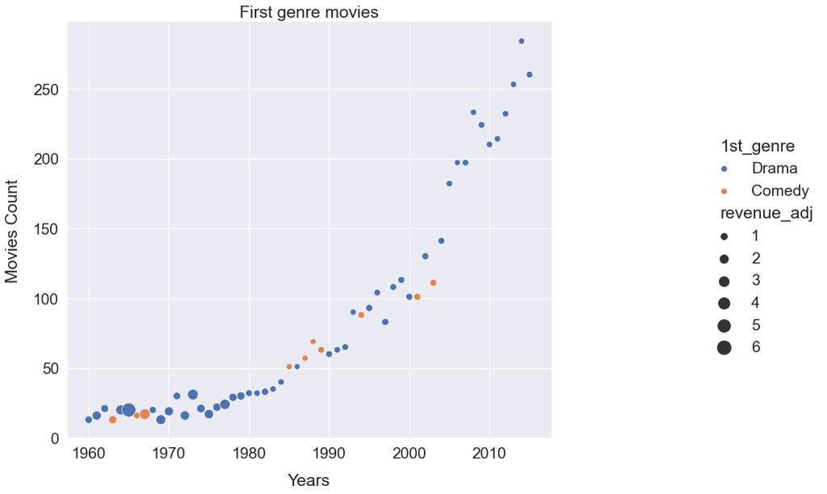

```python
genres_graph('1st_genre_count','1st_genre',"First genre movies");
```

> - **Drama Movies is most produced by so far**
> - **Average Revenues has reversible relation with movies count**
> - **Movies at year 1965 need more focus as they got max revenues**

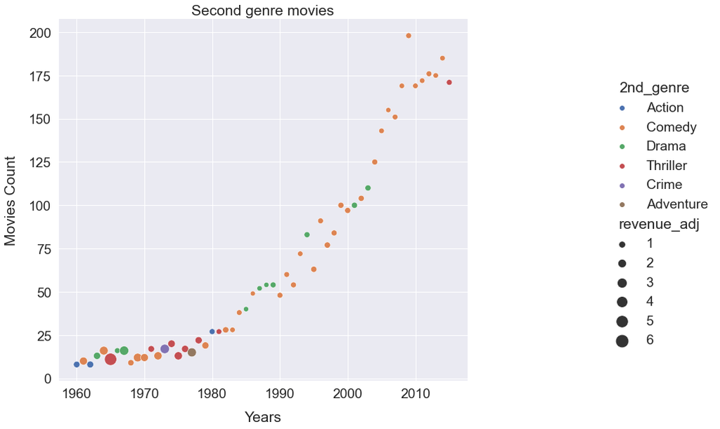

```python
genres_graph('2nd_genre_count','2nd_genre',"Second genre movies");
```

> - **Comedy Movies is the second best option since 1990**
> - **Average Revenues has reversible relation with movies count**
> - **Movies at year 1965 need more focus as they got max revenues**

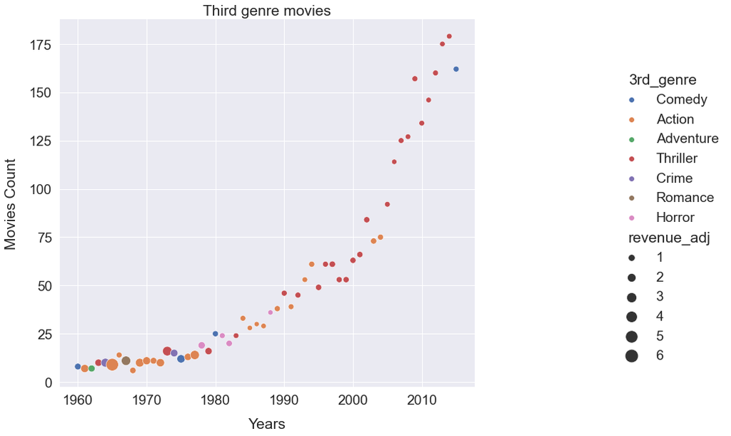

```python
genres_graph('3rd_genre_count','3rd_genre',"Third genre movies");
```

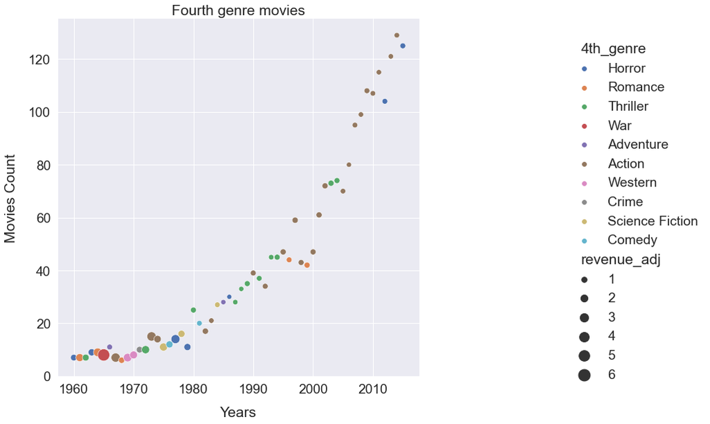

```python
genres_graph('4th_genre_count','4th_genre',"Fourth genre movies");
```

> - **Action Movies is the forth best option since 2000**
> - **Average Revenues has reversible relation with movies count**
> - **Movies at year 1965 need more focus as they got max revenues**

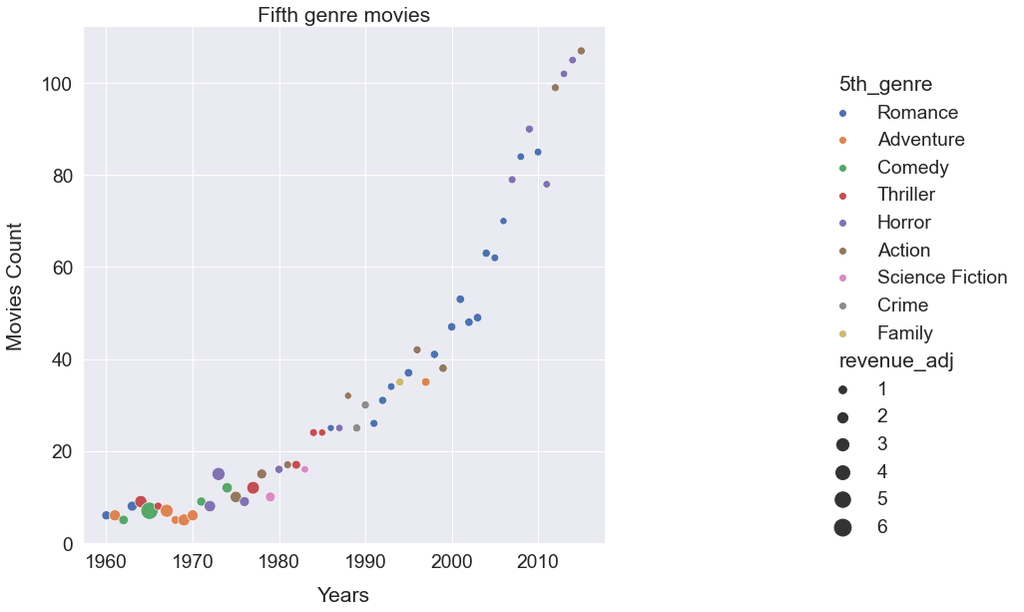

```python
genres_graph('5th_genre_count','5th_genre',"Fifth genre movies");
```

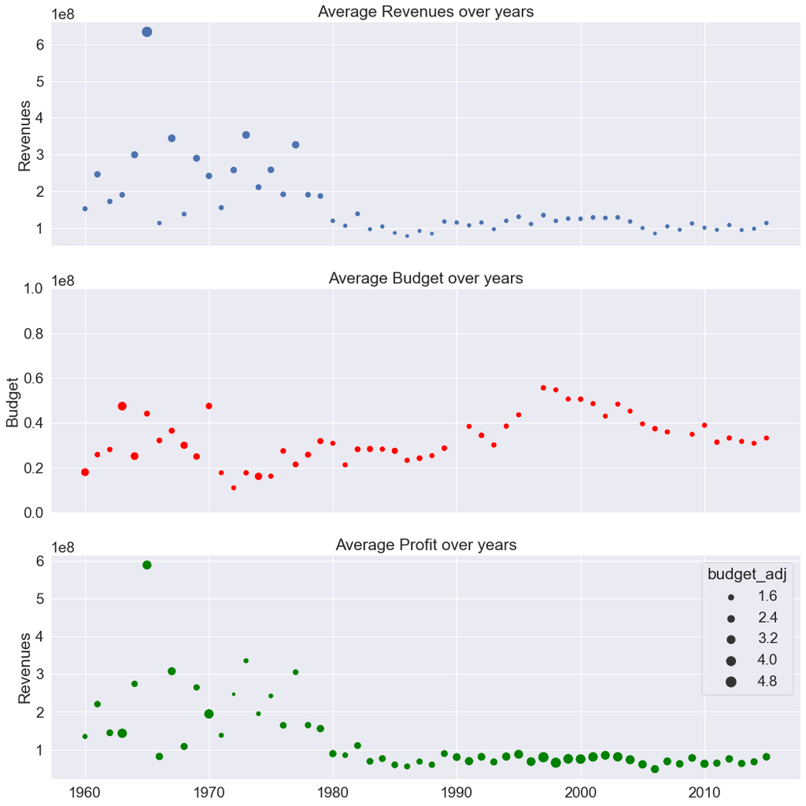

```python
f, axs = plt.subplots(3, 1, figsize=(15, 15),sharex=True)
sns.scatterplot(data=top_f, x="release_year", y="revenue_adj",size=
"revenue_adj" ,sizes=(30, 200),ax=axs[0],legend=False)
axs[0].set(xlabel= '', ylabel='Revenues', title='Average Revenues over years')



sns.scatterplot(data=top_f, x="release_year", y="budget_adj",size=
(df.revenue_adj-df.budget_adj) ,sizes=(30, 200),ax=axs[1],color="red",legend=False)
axs[1].set(xlabel= '', ylabel='Budget', title='Average Budget over years')
axs[1].set_ylim((0,100000000))

sns.scatterplot(data=top_f, x="release_year", y=(top_f.revenue_adj-top_f.budget_adj),size=
'budget_adj' ,sizes=(30, 200),ax=axs[2],color="green")
axs[2].set(xlabel= '', ylabel='Revenues', title='Average Profit over years')
f.tight_layout()
```

> - **Nowadays there is fierce competition between movies which is negative affecting revenues compared to early years in data set where movies counts through year was very low**
> - **More voting affeting negtivaley on voting average**
> - **Old movies has the least voting activity**
> - **Movies budget range is same since 1960 but profit margin decreased drastically**

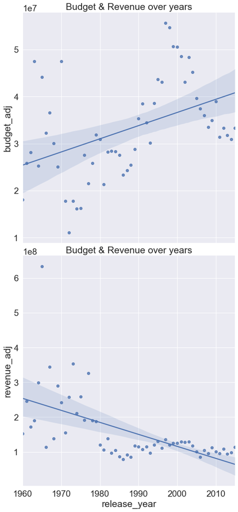

```python
g = sns.PairGrid(top_f, y_vars=["budget_adj", "revenue_adj"],x_vars=["release_year"], height=8)
g.map(sns.regplot)
g.set(title='Budget & Revenue over years')
```

> - **Even in years from 1990 to 2000 the budget was the highest, the revenue slighly increased.**

```python
df.info()
```

```
<class 'pandas.core.frame.DataFrame'>
Int64Index: 10865 entries, 0 to 10865
Data columns (total 35 columns):
 #   Column           Non-Null Count  Dtype
---  ------           --------------  -----
 0   id               10865 non-null  int64
 1   imdb_id          10855 non-null  object
 2   popularity       10865 non-null  float64
 3   original_title   10865 non-null  object
 4   cast             10789 non-null  object
 5   director         10821 non-null  object
 6   keywords         9372 non-null   object
 7   runtime          10865 non-null  int64
 8   genres           10842 non-null  object
 9   release_date     10865 non-null  datetime64[ns]
```

[output cut: 27 more lines]

### Research Question 2 (Is there releation between Revenues, voting and popularity)

```python
vote_popularity = pd.concat([df['original_title'],df['popularity'],df['vote_count']
                             ,df['vote_average'],df['runtime'],df['revenue_adj'],df['budget_adj'],genres],axis=1)
```

```python
vote_popularity.describe()
```

|  | popularity | vote_count | vote_average | runtime | revenue_adj | budget_adj | release_year | Action | Adventure | Animation | ... | History | Horror | Music | Mystery | Romance | Science Fiction | TV Movie | Thriller | War | Western |
| --- | --- | --- | --- | --- | --- | --- | --- | --- | --- | --- | --- | --- | --- | --- | --- | --- | --- | --- | --- | --- | --- |
| count | 10865.000000 | 10865.000000 | 10865.000000 | 10865.000000 | 4.849000e+03 | 5.169000e+03 | 10865.000000 | 10865.000000 | 10865.000000 | 10865.000000 | ... | 10865.000000 | 10865.000000 | 10865.000000 | 10865.000000 | 10865.000000 | 10865.000000 | 10865.000000 | 10865.000000 | 10865.000000 | 10865.000000 |
| mean | 0.646446 | 217.399632 | 5.975012 | 102.071790 | 1.151009e+08 | 3.688907e+07 | 2001.321859 | 0.219420 | 0.135389 | 0.064335 | ... | 0.030741 | 0.150667 | 0.037552 | 0.074551 | 0.157570 | 0.113116 | 0.015370 | 0.267556 | 0.024850 | 0.015186 |
| std | 1.000231 | 575.644627 | 0.935138 | 31.382701 | 1.988557e+08 | 4.196096e+07 | 12.813260 | 0.413873 | 0.342154 | 0.245360 | ... | 0.172623 | 0.357741 | 0.190118 | 0.262678 | 0.364354 | 0.316749 | 0.123027 | 0.442705 | 0.155676 | 0.122299 |
| min | 0.000065 | 10.000000 | 1.500000 | 0.000000 | 2.370705e+00 | 9.210911e-01 | 1960.000000 | 0.000000 | 0.000000 | 0.000000 | ... | 0.000000 | 0.000000 | 0.000000 | 0.000000 | 0.000000 | 0.000000 | 0.000000 | 0.000000 | 0.000000 | 0.000000 |
| 25% | 0.207575 | 17.000000 | 5.400000 | 90.000000 | 1.046585e+07 | 8.102293e+06 | 1995.000000 | 0.000000 | 0.000000 | 0.000000 | ... | 0.000000 | 0.000000 | 0.000000 | 0.000000 | 0.000000 | 0.000000 | 0.000000 | 0.000000 | 0.000000 | 0.000000 |
| 50% | 0.383831 | 38.000000 | 6.000000 | 99.000000 | 4.395666e+07 | 2.271505e+07 | 2006.000000 | 0.000000 | 0.000000 | 0.000000 | ... | 0.000000 | 0.000000 | 0.000000 | 0.000000 | 0.000000 | 0.000000 | 0.000000 | 0.000000 | 0.000000 | 0.000000 |
| 75% | 0.713857 | 146.000000 | 6.600000 | 111.000000 | 1.316482e+08 | 5.008384e+07 | 2011.000000 | 0.000000 | 0.000000 | 0.000000 | ... | 0.000000 | 0.000000 | 0.000000 | 0.000000 | 0.000000 | 0.000000 | 0.000000 | 1.000000 | 0.000000 | 0.000000 |
| max | 32.985763 | 9767.000000 | 9.200000 | 900.000000 | 2.827124e+09 | 4.250000e+08 | 2015.000000 | 1.000000 | 1.000000 | 1.000000 | ... | 1.000000 | 1.000000 | 1.000000 | 1.000000 | 1.000000 | 1.000000 | 1.000000 | 1.000000 | 1.000000 | 1.000000 |

8 rows × 27 columns

```python
vote_popularity[vote_popularity['runtime']<60].sort_values(by = 'vote_count',ascending = False)
```

|  | original_title | popularity | vote_count | vote_average | runtime | revenue_adj | budget_adj | release_year | Action | Adventure | ... | History | Horror | Music | Mystery | Romance | Science Fiction | TV Movie | Thriller | War | Western |
| --- | --- | --- | --- | --- | --- | --- | --- | --- | --- | --- | --- | --- | --- | --- | --- | --- | --- | --- | --- | --- | --- |
| 4434 | Paperman | 1.182679 | 507 | 8.0 | 7 | NaN | NaN | 2012 | 0 | 0 | ... | 0 | 0 | 0 | 0 | 1 | 0 | 0 | 0 | 0 | 0 |
| 159 | Kung Fury | 0.953046 | 487 | 7.7 | 31 | NaN | 579617.224968 | 2015 | 1 | 0 | ... | 0 | 0 | 0 | 0 | 0 | 1 | 0 | 0 | 0 | 0 |
| 100 | Frozen Fever | 1.724712 | 475 | 7.0 | 8 | NaN | NaN | 2015 | 0 | 1 | ... | 0 | 0 | 0 | 0 | 0 | 0 | 0 | 0 | 0 | 0 |
| 826 | Feast | 0.705700 | 318 | 8.0 | 6 | NaN | NaN | 2014 | 0 | 0 | ... | 0 | 0 | 0 | 0 | 1 | 0 | 0 | 0 | 0 | 0 |
| 216 | Lava | 0.640151 | 298 | 7.3 | 7 | NaN | NaN | 2015 | 0 | 0 | ... | 0 | 0 | 1 | 0 | 0 | 0 | 0 | 0 | 0 | 0 |
| ... | ... | ... | ... | ... | ... | ... | ... | ... | ... | ... | ... | ... | ... | ... | ... | ... | ... | ... | ... | ... | ... |
| 4836 | Head Over Heels | 0.134777 | 10 | 6.6 | 10 | NaN | 9877.340526 | 2012 | 0 | 0 | ... | 0 | 0 | 0 | 0 | 1 | 0 | 0 | 0 | 0 | 0 |
| 1385 | Emmet Otter's Jug-Band Christmas | 0.002457 | 10 | 7.5 | 48 | NaN | NaN | 1977 | 0 | 0 | ... | 0 | 0 | 0 | 0 | 0 | 0 | 0 | 0 | 0 | 0 |
| 6040 | The Vatican Exorcisms | 0.011798 | 10 | 4.7 | 0 | NaN | NaN | 2013 | 0 | 0 | ... | 0 | 1 | 0 | 1 | 0 | 0 | 0 | 0 | 0 | 0 |
| 5800 | Alpha and Omega 2: A Howl-iday Adventure | 0.280550 | 10 | 5.6 | 45 | NaN | NaN | 2013 | 0 | 1 | ... | 0 | 0 | 0 | 0 | 0 | 0 | 0 | 0 | 0 | 0 |
| 7773 | The Secret Life of Brian | 0.118821 | 10 | 7.2 | 50 | NaN | NaN | 2007 | 0 | 0 | ... | 0 | 0 | 0 | 0 | 0 | 0 | 0 | 0 | 0 | 0 |

318 rows × 28 columns

#### Run time column is not accurate so it will be removed from analysis

```python
vote_popularity.drop(['runtime'],axis=1,inplace=True)
```

```python
# Average popularity,vote_count, vote_average, runtime per year
vote_popularity.groupby(['release_year'],as_index=False)['popularity','vote_count','vote_average'].mean()
```

|  | release_year | popularity | vote_count | vote_average |
| --- | --- | --- | --- | --- |
| 0 | 1960 | 0.458932 | 77.531250 | 6.325000 |
| 1 | 1961 | 0.422827 | 77.580645 | 6.374194 |
| 2 | 1962 | 0.454783 | 74.750000 | 6.343750 |
| 3 | 1963 | 0.502706 | 82.823529 | 6.329412 |
| 4 | 1964 | 0.412428 | 74.690476 | 6.211905 |
| 5 | 1965 | 0.342587 | 52.000000 | 6.194286 |
| 6 | 1966 | 0.304112 | 31.739130 | 6.128261 |
| 7 | 1967 | 0.471154 | 77.550000 | 6.242500 |
| 8 | 1968 | 0.484202 | 108.128205 | 6.379487 |
| 9 | 1969 | 0.422778 | 55.903226 | 5.961290 |
| 10 | 1970 | 0.341700 | 49.048780 | 6.417073 |
| 11 | 1971 | 0.448112 | 92.381818 | 6.420000 |
| 12 | 1972 | 0.449054 | 135.825000 | 6.535000 |
| 13 | 1973 | 0.494462 | 94.054545 | 6.703636 |
| 14 | 1974 | 0.447829 | 110.787234 | 6.395745 |
| 15 | 1975 | 0.519445 | 138.363636 | 6.390909 |
| 16 | 1976 | 0.474516 | 100.425532 | 6.340426 |
| 17 | 1977 | 0.626387 | 140.894737 | 6.147368 |
| 18 | 1978 | 0.413314 | 75.353846 | 6.130769 |
| 19 | 1979 | 0.589312 | 154.912281 | 6.308772 |
| 20 | 1980 | 0.495652 | 139.717949 | 6.160256 |
| 21 | 1981 | 0.442413 | 91.219512 | 6.165854 |
| 22 | 1982 | 0.543353 | 140.555556 | 6.241975 |
| 23 | 1983 | 0.541445 | 123.575000 | 5.971250 |
| 24 | 1984 | 0.590843 | 146.390476 | 6.003810 |
| 25 | 1985 | 0.584058 | 126.247706 | 6.177064 |
| 26 | 1986 | 0.509545 | 113.016529 | 6.004959 |
| 27 | 1987 | 0.504637 | 120.512000 | 6.128800 |
| 28 | 1988 | 0.465039 | 100.524138 | 5.965517 |
| 29 | 1989 | 0.563658 | 136.182482 | 6.070073 |
| 30 | 1990 | 0.535735 | 163.446970 | 5.993939 |
| 31 | 1991 | 0.501090 | 127.864662 | 6.014286 |
| 32 | 1992 | 0.582913 | 146.218045 | 6.081203 |
| 33 | 1993 | 0.547056 | 136.426966 | 6.050000 |
| 34 | 1994 | 0.668825 | 204.298913 | 5.942391 |
| 35 | 1995 | 0.710722 | 204.628571 | 6.056000 |
| 36 | 1996 | 0.604768 | 127.602941 | 5.900980 |
| 37 | 1997 | 0.712003 | 213.463542 | 5.988542 |
| 38 | 1998 | 0.626165 | 190.676190 | 5.970476 |
| 39 | 1999 | 0.645799 | 238.602679 | 6.032589 |
| 40 | 2000 | 0.546799 | 203.550661 | 5.882379 |
| 41 | 2001 | 0.702658 | 260.570248 | 5.896281 |
| 42 | 2002 | 0.701454 | 236.481203 | 5.973308 |
| 43 | 2003 | 0.719083 | 243.505338 | 5.930961 |
| 44 | 2004 | 0.722438 | 257.980456 | 5.988599 |
| 45 | 2005 | 0.628663 | 201.472527 | 5.866484 |
| 46 | 2006 | 0.606371 | 186.477941 | 5.941422 |
| 47 | 2007 | 0.593161 | 206.372146 | 5.964384 |
| 48 | 2008 | 0.584817 | 206.778226 | 5.930847 |
| 49 | 2009 | 0.600178 | 224.557223 | 5.856660 |
| 50 | 2010 | 0.645058 | 265.928425 | 5.992843 |
| 51 | 2011 | 0.675069 | 250.812963 | 5.958519 |
| 52 | 2012 | 0.607197 | 312.141156 | 5.799830 |
| 53 | 2013 | 0.627627 | 325.471927 | 5.880577 |
| 54 | 2014 | 0.887268 | 294.660000 | 5.920714 |
| 55 | 2015 | 1.030657 | 290.019078 | 5.885692 |

```python
vote_popularity.groupby(['release_year'],as_index=False)['popularity','vote_count','vote_average'].max()
```

|  | release_year | popularity | vote_count | vote_average |
| --- | --- | --- | --- | --- |
| 0 | 1960 | 2.610362 | 1180 | 8.0 |
| 1 | 1961 | 2.631987 | 913 | 7.5 |
| 2 | 1962 | 3.170651 | 560 | 7.7 |
| 3 | 1963 | 2.508235 | 486 | 7.5 |
| 4 | 1964 | 3.153791 | 804 | 7.7 |
| 5 | 1965 | 1.910465 | 620 | 7.6 |
| 6 | 1966 | 1.227582 | 286 | 7.9 |
| 7 | 1967 | 2.550704 | 928 | 7.6 |
| 8 | 1968 | 3.309196 | 1708 | 7.7 |
| 9 | 1969 | 1.778746 | 379 | 7.3 |
| 10 | 1970 | 1.936962 | 625 | 7.6 |
| 11 | 1971 | 3.072555 | 1786 | 7.7 |
| 12 | 1972 | 5.738034 | 3970 | 8.3 |
| 13 | 1973 | 2.272486 | 1113 | 7.7 |
| 14 | 1974 | 3.264571 | 2131 | 8.1 |
| 15 | 1975 | 3.258151 | 1612 | 8.0 |
| 16 | 1976 | 2.582657 | 1269 | 7.8 |
| 17 | 1977 | 12.037933 | 4428 | 7.9 |
| 18 | 1978 | 1.697618 | 786 | 8.0 |
| 19 | 1979 | 4.935897 | 2724 | 7.8 |
| 20 | 1980 | 5.488441 | 3954 | 8.0 |
| 21 | 1981 | 4.578300 | 2506 | 8.5 |
| 22 | 1982 | 4.215642 | 2110 | 7.9 |
| 23 | 1983 | 4.828854 | 3101 | 8.1 |
| 24 | 1984 | 4.831966 | 2692 | 8.4 |
| 25 | 1985 | 6.095293 | 3785 | 8.3 |
| 26 | 1986 | 2.485419 | 2027 | 8.0 |
| 27 | 1987 | 3.474728 | 1311 | 7.7 |
| 28 | 1988 | 3.777441 | 2800 | 8.0 |
| 29 | 1989 | 4.143585 | 2436 | 8.4 |
| 30 | 1990 | 2.679627 | 1939 | 8.0 |
| 31 | 1991 | 3.852269 | 2836 | 7.9 |
| 32 | 1992 | 4.586426 | 2121 | 8.4 |
| 33 | 1993 | 2.571339 | 3169 | 8.1 |
| 34 | 1994 | 8.093754 | 5754 | 8.4 |
| 35 | 1995 | 4.765359 | 3535 | 8.5 |
| 36 | 1996 | 4.480733 | 2000 | 7.9 |
| 37 | 1997 | 6.668990 | 4654 | 7.8 |
| 38 | 1998 | 4.180540 | 3396 | 8.0 |
| 39 | 1999 | 8.947905 | 6351 | 8.1 |
| 40 | 2000 | 4.271452 | 3531 | 8.5 |
| 41 | 2001 | 8.575419 | 6079 | 8.0 |
| 42 | 2002 | 8.095275 | 5114 | 8.3 |
| 43 | 2003 | 7.122455 | 5636 | 8.0 |
| 44 | 2004 | 5.827781 | 3550 | 7.8 |
| 45 | 2005 | 5.939927 | 4914 | 8.3 |
| 46 | 2006 | 5.838503 | 3181 | 8.7 |
| 47 | 2007 | 4.965391 | 3428 | 7.9 |
| 48 | 2008 | 8.466668 | 8432 | 8.5 |
| 49 | 2009 | 9.432768 | 8458 | 8.3 |
| 50 | 2010 | 9.363643 | 9767 | 8.8 |
| 51 | 2011 | 8.411577 | 5025 | 9.2 |
| 52 | 2012 | 7.637767 | 8903 | 8.3 |
| 53 | 2013 | 6.112766 | 6882 | 8.5 |
| 54 | 2014 | 24.949134 | 6498 | 8.8 |
| 55 | 2015 | 32.985763 | 6185 | 8.9 |

```python
vote_popularity.groupby(['release_year'],as_index=False)['popularity','vote_count','vote_average'].min()
```

|  | release_year | popularity | vote_count | vote_average |
| --- | --- | --- | --- | --- |
| 0 | 1960 | 0.055821 | 10 | 4.9 |
| 1 | 1961 | 0.027527 | 10 | 4.6 |
| 2 | 1962 | 0.038819 | 10 | 4.9 |
| 3 | 1963 | 0.045417 | 10 | 5.0 |
| 4 | 1964 | 0.008990 | 10 | 4.6 |
| 5 | 1965 | 0.004770 | 10 | 4.4 |
| 6 | 1966 | 0.034555 | 10 | 1.5 |
| 7 | 1967 | 0.034181 | 10 | 4.6 |
| 8 | 1968 | 0.005265 | 10 | 5.4 |
| 9 | 1969 | 0.002757 | 10 | 3.9 |
| 10 | 1970 | 0.020760 | 10 | 3.0 |
| 11 | 1971 | 0.000188 | 10 | 2.9 |
| 12 | 1972 | 0.024345 | 10 | 5.3 |
| 13 | 1973 | 0.021941 | 10 | 4.8 |
| 14 | 1974 | 0.029670 | 10 | 4.8 |
| 15 | 1975 | 0.017468 | 10 | 3.8 |
| 16 | 1976 | 0.002381 | 10 | 4.6 |
| 17 | 1977 | 0.002457 | 10 | 4.6 |
| 18 | 1978 | 0.044675 | 10 | 3.1 |
| 19 | 1979 | 0.019263 | 10 | 3.0 |
| 20 | 1980 | 0.031133 | 10 | 3.6 |
| 21 | 1981 | 0.046679 | 10 | 4.2 |
| 22 | 1982 | 0.003659 | 10 | 3.0 |
| 23 | 1983 | 0.002120 | 10 | 2.7 |
| 24 | 1984 | 0.059713 | 10 | 3.6 |
| 25 | 1985 | 0.000065 | 10 | 4.3 |
| 26 | 1986 | 0.001567 | 10 | 3.5 |
| 27 | 1987 | 0.005529 | 10 | 2.8 |
| 28 | 1988 | 0.001662 | 10 | 3.8 |
| 29 | 1989 | 0.010016 | 10 | 2.3 |
| 30 | 1990 | 0.024987 | 10 | 3.8 |
| 31 | 1991 | 0.048237 | 10 | 3.1 |
| 32 | 1992 | 0.006863 | 10 | 4.0 |
| 33 | 1993 | 0.012941 | 10 | 3.4 |
| 34 | 1994 | 0.061916 | 10 | 3.9 |
| 35 | 1995 | 0.013131 | 10 | 3.5 |
| 36 | 1996 | 0.028143 | 10 | 3.3 |
| 37 | 1997 | 0.022145 | 10 | 3.2 |
| 38 | 1998 | 0.029699 | 10 | 2.9 |
| 39 | 1999 | 0.015074 | 10 | 3.4 |
| 40 | 2000 | 0.004010 | 10 | 3.5 |
| 41 | 2001 | 0.001349 | 10 | 3.6 |
| 42 | 2002 | 0.009266 | 10 | 3.3 |
| 43 | 2003 | 0.013546 | 10 | 3.4 |
| 44 | 2004 | 0.001117 | 10 | 2.1 |
| 45 | 2005 | 0.000973 | 10 | 2.5 |
| 46 | 2006 | 0.001115 | 10 | 2.8 |
| 47 | 2007 | 0.004196 | 10 | 1.5 |
| 48 | 2008 | 0.001317 | 10 | 2.6 |
| 49 | 2009 | 0.001423 | 10 | 3.1 |
| 50 | 2010 | 0.004433 | 10 | 2.1 |
| 51 | 2011 | 0.002006 | 10 | 2.1 |
| 52 | 2012 | 0.001372 | 10 | 2.0 |
| 53 | 2013 | 0.000620 | 10 | 2.2 |
| 54 | 2014 | 0.002599 | 10 | 2.4 |
| 55 | 2015 | 0.003920 | 10 | 2.4 |

```python
vote_popularity.info()
```

```
<class 'pandas.core.frame.DataFrame'>
Int64Index: 10865 entries, 0 to 10865
Data columns (total 27 columns):
 #   Column           Non-Null Count  Dtype
---  ------           --------------  -----
 0   original_title   10865 non-null  object
 1   popularity       10865 non-null  float64
 2   vote_count       10865 non-null  int64
 3   vote_average     10865 non-null  float64
 4   revenue_adj      4849 non-null   float64
 5   budget_adj       5169 non-null   float64
 6   release_year     10865 non-null  int64
 7   Action           10865 non-null  int64
 8   Adventure        10865 non-null  int64
 9   Animation        10865 non-null  int64
```

[output cut: 19 more lines]

```python
sns.set_theme(font_scale=1.5)

g = sns.FacetGrid(vote_popularity, col="release_year",col_wrap=4,height=4, aspect=1)
g.map_dataframe(sns.scatterplot, y="popularity", x="vote_count", hue="vote_average", size='revenue_adj', palette="hls",sizes=(20, 120)).add_legend()
g.set( xlim=(0, 6000), ylim=(0, 25));
```

[output not shown]

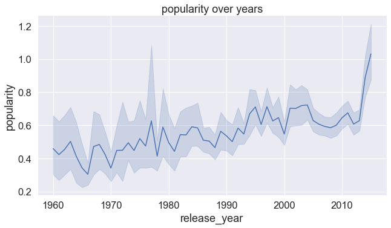

```python
sns.set_theme(font_scale=1.5)
g= sns.relplot(data=vote_popularity, x='release_year', y='popularity',kind='line')
g.fig.set_size_inches(10, 5)
g.set(title='popularity over years');
```

> - **Old movies has the least voting activity**
> - **Movies from last couple of years in data set are the most popular**

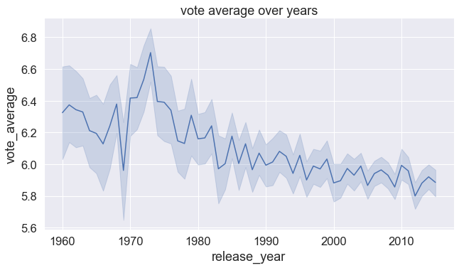

```python
sns.set_theme(font_scale=1.5)
g= sns.relplot(data=vote_popularity, x='release_year', y='vote_average',kind='line')
g.fig.set_size_inches(10,5)
g.set(title='vote average over years');
```

> - **More votes less vote average**

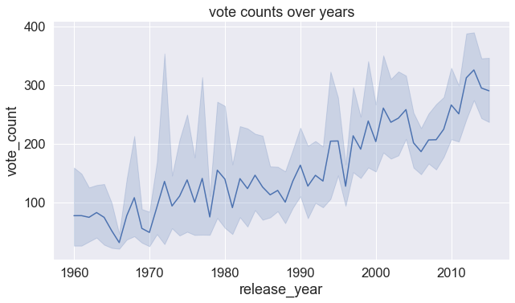

```python
sns.set_theme(font_scale=1.5)
g= sns.relplot(data=vote_popularity, x='release_year', y='vote_count',kind='line')
g.fig.set_size_inches(10,5)
g.set(title='vote counts over years');
```

> - **More votes less vote average**

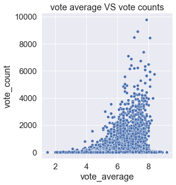

```python
sns.relplot(
    data=vote_popularity,
    x="vote_average", y="vote_count").set(title='vote average VS vote counts')
```

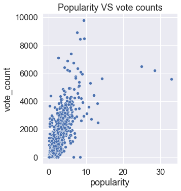

```python
sns.relplot(
    data=vote_popularity,
    x="popularity", y="vote_count").set(title='Popularity VS vote counts');
```

> - **There is a direct relation between popularity and votes counts.**

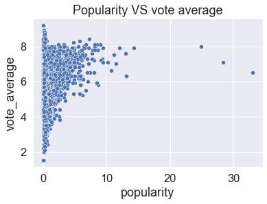

```python
sns.scatterplot(data=vote_popularity, x="popularity", y="vote_average").set(title='Popularity VS vote average');
```

> - **Very top rated movies are not popular at all**

```python
# Continue to explore the data to address your additional research
#   questions. Add more headers as needed if you have more questions to
#   investigate.
```

## Conclusions

> - **Year 1965 was the most successful year**
> - **Nowadays there is fierce competition between movies which is negative affecting revenues compared to early years in data set where movies counts through year was very low**
> - **More voting affeting negtivaley on voting average**
> - **Drama movies category is the most successful category and most produced**
> - **Thriller movies can be good investment as it's mostly 3rd or 2nd genres every year**
> - **Old movies has the least voting activity**
> - **Movies budget range is same since 1960 but profit margin decreased drastically**

### limitations

> - **0 Values in revenues_adj and budget_adj**
> - **run time is not accurate**

```python
from subprocess import call
call(['python', '-m', 'nbconvert', 'Investigate_a_Dataset.ipynb'])
```

```
4294967295
```